# Statistics

2025-12-30

# Statistical analyses

This document incudes the code for running all the statistical analyses of the mealworm and superworm gut microbiome data reported in this study. It includes the alpha-diversity, beta-diversity, and differential abundance analyses.

# Load required libraries

```r
library(lme4)
library(phyloseq)
library(car)
library(emmeans)
library(ggplot2)
library(patchwork)
library(vegan)
library(dplyr)
library(tidyr)
library(kableExtra)
library(ANCOMBC)
```

# Analyses of the standard diet across species

## Prepare a phyloseq object for the standard diets for both insects

Use the MAG abundance data and the GTDB-Tk output data to generate a phyloseq object.

```r
# Load the OTU table
otumat <- as.matrix(read.table("standard_MAG_abundances_depth.txt",
                        header = TRUE, row.names = 1))

# Load the taxonomy table
taxmat <- as.matrix(read.table("standard_MAG_taxonomy.txt",
                        header = TRUE, row.names = 1))

# Load the sample metadata
metadata <- read.table("standard_sample_metadata.txt",
                       header = TRUE, row.names = 1)

# Combine the data into a phyloseq object
OTU <- otu_table(otumat, taxa_are_rows = TRUE)
TAX <- tax_table(taxmat)
META <- sample_data(metadata)
ps <- phyloseq(OTU, TAX, META)

# Convert MAG abundances to percentages
ps.rel <- transform_sample_counts(ps, function(x) x / sum(x))
```

## Calculate alpha-diversity for the standard diets and perform statistical analysis

```r
# Calculate alpha-diversity metrics
richness <- estimate_richness(ps.rel, measures = c("Shannon", "Simpson"))

# Add columns with relevant metadata
richness$insect <- metadata$Insect
richness$replicate <- metadata$Replicate
richness$batch <- metadata$Insect_batch

# Create factors for treatment, ordering the treatments as desired
richness$treatment <- factor(richness$insect,
                                 levels = c("Mealworm", "Superworm"))

# Perform statistical analysis on the Shannon data
model.shannon <- lmer(log(Shannon) ~ insect + (1 | replicate), data=richness)
summary(model.shannon)
```

```
## Linear mixed model fit by REML ['lmerMod']
## Formula: log(Shannon) ~ insect + (1 | replicate)
##    Data: richness
##
## REML criterion at convergence: 6.6
##
## Scaled residuals:
##     Min      1Q  Median      3Q     Max
## -2.1115 -0.3492  0.3184  0.4812  1.2360
##
## Random effects:
##  Groups    Name        Variance Std.Dev.
##  replicate (Intercept) 0.00000  0.0000
##  Residual              0.09014  0.3002
## Number of obs: 10, groups:  replicate, 6
##
## Fixed effects:
##                 Estimate Std. Error t value
## (Intercept)       0.6639     0.1501   4.423
## insectSuperworm   0.1863     0.1938   0.961
##
## Correlation of Fixed Effects:
##             (Intr)
## insctSprwrm -0.775
## optimizer (nloptwrap) convergence code: 0 (OK)
## boundary (singular) fit: see help('isSingular')
```

```r
model.shannon.aov <- Anova(model.shannon, type = 2)
model.shannon.aov
```

```
## Analysis of Deviance Table (Type II Wald chisquare tests)
##
## Response: log(Shannon)
##         Chisq Df Pr(>Chisq)
## insect 0.9238  1     0.3365
```

```r
model.shannon.em <- emmeans(model.shannon, pairwise ~ insect,
                            infer = TRUE, type = "response")
model.shannon.em$emmeans
```

```
##  insect    response    SE df lower.CL upper.CL null t.ratio p.value
##  Mealworm      1.94 0.322  8     1.32     2.85    1   4.000  0.0039
##  Superworm     2.34 0.287  8     1.76     3.10    1   6.936  0.0001
##
## Degrees-of-freedom method: kenward-roger
## Confidence level used: 0.95
## Intervals are back-transformed from the log scale
## Tests are performed on the log scale
```

```r
model.shannon.em$contrasts
```

```
##  contrast             ratio    SE   df lower.CL upper.CL null t.ratio p.value
##  Mealworm / Superworm  0.83 0.171 4.32    0.476     1.45    1  -0.903  0.4141
##
## Degrees-of-freedom method: kenward-roger
## Confidence level used: 0.95
## Intervals are back-transformed from the log scale
## Tests are performed on the log scale
```

```r
# Perform statistical analysis on the Simpson data
model.simpson <- lmer(log(Simpson) ~ insect + (1 | replicate), data=richness)
summary(model.simpson)
```

```
## Linear mixed model fit by REML ['lmerMod']
## Formula: log(Simpson) ~ insect + (1 | replicate)
##    Data: richness
##
## REML criterion at convergence: -3.9
##
## Scaled residuals:
##     Min      1Q  Median      3Q     Max
## -1.7916 -0.7146  0.3618  0.5861  1.2689
##
## Random effects:
##  Groups    Name        Variance Std.Dev.
##  replicate (Intercept) 0.00000  0.0000
##  Residual              0.02409  0.1552
## Number of obs: 10, groups:  replicate, 6
##
## Fixed effects:
##                 Estimate Std. Error t value
## (Intercept)     -0.26393    0.07760  -3.401
## insectSuperworm  0.01756    0.10018   0.175
##
## Correlation of Fixed Effects:
##             (Intr)
## insctSprwrm -0.775
## optimizer (nloptwrap) convergence code: 0 (OK)
## boundary (singular) fit: see help('isSingular')
```

```r
model.simpson.aov <- Anova(model.simpson, type = 2)
model.simpson.aov
```

```
## Analysis of Deviance Table (Type II Wald chisquare tests)
##
## Response: log(Simpson)
##         Chisq Df Pr(>Chisq)
## insect 0.0307  1     0.8609
```

```r
model.simpson.em <- emmeans(model.simpson, pairwise ~ insect,
                            infer = TRUE, type = "response")
model.simpson.em$emmeans
```

```
##  insect    response     SE df lower.CL upper.CL null t.ratio p.value
##  Mealworm     0.768 0.0659  8    0.630    0.936    1  -3.076  0.0152
##  Superworm    0.782 0.0495  8    0.675    0.905    1  -3.888  0.0046
##
## Degrees-of-freedom method: kenward-roger
## Confidence level used: 0.95
## Intervals are back-transformed from the log scale
## Tests are performed on the log scale
```

```r
model.simpson.em$contrasts
```

```
##  contrast             ratio    SE   df lower.CL upper.CL null t.ratio p.value
##  Mealworm / Superworm 0.983 0.105 4.32    0.737     1.31    1  -0.165  0.8767
##
## Degrees-of-freedom method: kenward-roger
## Confidence level used: 0.95
## Intervals are back-transformed from the log scale
## Tests are performed on the log scale
```

## Plot the alpha-diversity metrics for the standard diets

Generate plots showing the Shannon and Simpson’s diversity metrics

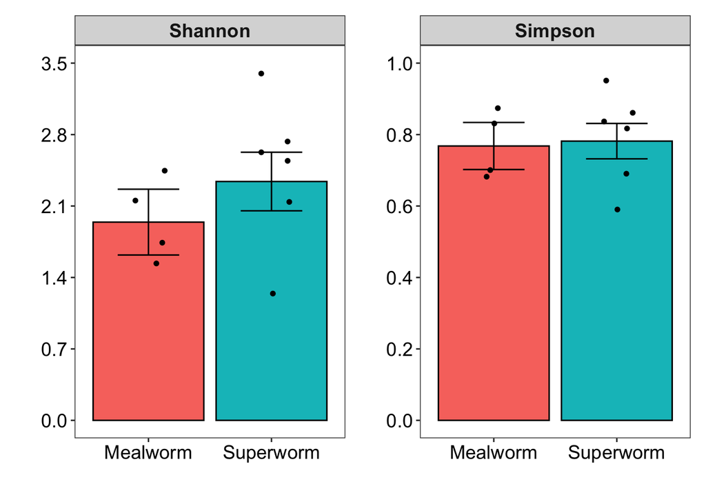

```r
# Collect the emmeans for Shannon data
emms.shannon <- as.data.frame(model.shannon.em$emmeans)
emms.shannon$metric <- 'Shannon'

# Collect the emmeans for teh Simpson's data
emms.simpson <- as.data.frame(model.simpson.em$emmeans)
emms.simpson$metric <- 'Simpson'

# Plot the Shannon data
p.shannon <- ggplot() +
  geom_bar(data = emms.shannon,
           aes(x = insect, y = response, fill = insect),
           stat = "identity",
           colour = "black") +
  geom_errorbar(data = emms.shannon,
                aes(x = insect, ymin = response-SE, ymax = response+SE),
                stat = "identity", width = 0.5, size = 0.5) +
  geom_jitter(data = richness,
              aes(x = insect, y = Shannon),
              width = 0.15, size = 1.25) +
  facet_wrap(~metric, scales="free_y") +
  theme_bw() +
  theme(text = element_text(size = 17), legend.position = "none",
        panel.grid.major = element_blank(),
        panel.grid.minor = element_blank(),
        strip.text.x = element_text(face="bold"),
        axis.text.x = element_text(color="black"),
        axis.text.y = element_text(color="black")) +
  scale_y_continuous(lim=c(0,3.5), breaks=c(0.0,0.7,1.4,2.1,2.8,3.5)) +
  xlab("") + ylab("")

# Plot the Simpson's data
p.simpson <- ggplot() +
  geom_bar(data = emms.simpson,
           aes(x = insect, y = response, fill = insect),
           stat = "identity",
           colour = "black") +
  geom_errorbar(data = emms.simpson,
                aes(x = insect, ymin = response-SE, ymax = response+SE),
                stat = "identity", width = 0.5, size = 0.5) +
  geom_jitter(data = richness,
              aes(x = insect, y = Simpson),
              width = 0.15, size = 1.25) +
  facet_wrap(~metric, scales="free_y") +
  theme_bw() +
  theme(text = element_text(size = 17), legend.position = "none",
        panel.grid.major = element_blank(),
        panel.grid.minor = element_blank(),
        strip.text.x = element_text(face="bold"),
        axis.text.x = element_text(color="black"),
        axis.text.y = element_text(color="black")) +
  scale_y_continuous(lim=c(0,1), breaks=c(0.0,0.2,0.4,0.6,0.8,1.0)) +
  xlab("") + ylab("")

# Combine the plots as two panels in one figure
p.shannon + p.simpson
```

```r
# Export a PDF of the figure
pdf('Standard.alpha.pdf', width=10, height=5)
p.shannon + p.simpson
dev.off()
```

## Calculate beta-diversity and make a PCoA plot at the species level to compare insect species

```r
# Summarize at the species level, removing taxa not classified at the species level
ps.rel.sp <- tax_glom(ps.rel, "Species", NArm = TRUE)

# Calculate the bray curtis distances
dist_bc <- phyloseq::distance(ps.rel.sp, method = "bray")

# Extract sample data
meta <- data.frame(sample_data(ps.rel.sp))

# Perform a permutation test to test if the data meet the assumptions of PERMANOVA
beta.bray <- betadisper(dist_bc, meta$Insect, type = "centroid", bias.adjust = TRUE)
permdisp <- permutest(beta.bray, pairwise = TRUE, permutations = 10000)
permdisp
```

```
##
## Permutation test for homogeneity of multivariate dispersions
## Permutation: free
## Number of permutations: 10000
##
## Response: Distances
##           Df   Sum Sq   Mean Sq      F N.Perm Pr(>F)
## Groups     1 0.003454 0.0034545 0.2687  10000 0.6168
## Residuals  8 0.102867 0.0128584
##
## Pairwise comparisons:
## (Observed p-value below diagonal, permuted p-value above diagonal)
##           Mealworm Superworm
## Mealworm              0.5954
## Superworm  0.61826
```

```r
# Run the PERMANOVA test
adonis.bray <- adonis2(dist_bc ~ Insect, data = meta, permutations = 10000, by = "terms")
as.data.frame(adonis.bray)
```

```
##          Df SumOfSqs      R2        F     Pr(>F)
## Insect    1 1.185173 0.35899 4.480305 0.00549945
## Residual  8 2.116237 0.64101       NA         NA
## Total     9 3.301410 1.00000       NA         NA
```

```r
# Create a PCoA plot
pso <- ordinate(ps.rel.sp, "PCoA", "bray")
var_explained <- pso$values$Relative_eig * 100
ordplot5 <- plot_ordination(ps.rel.sp, pso, type="samples", color="Insect", axes = c(1,2))
p.beta.sp <- ordplot5 +  theme_bw() + theme(text = element_text(size = 17), aspect.ratio = 1) +
  geom_point(size = 4) +
  geom_point(size = 4, shape=21, stroke=0.5, color="black") +
  theme_bw() +
  theme(text = element_text(size = 17),
        panel.grid.major = element_blank(),
        panel.grid.minor = element_blank(),
        legend.position = "none") +
  labs(x = paste0(" PC1 [", round(var_explained[1], 1), "%]"),
       y = paste0(" PC2 [", round(var_explained[2], 1), "%]")) +
  scale_x_continuous(lim=c(-0.50,0.50), breaks=c(-0.50,-0.25,0.00,0.25,0.50),
                     labels = function(x) sprintf("%.2f", x)) +
  scale_y_continuous(lim=c(-0.25,0.75), breaks=c(-0.25,0.00,0.25,0.50,0.75),
                     labels = function(x) sprintf("%.2f", x))
```

## Calculate beta-diversity and make a PCoA plot at the genus level to compare insect species

```r
# Summarize at the species level, removing taxa not classified at the species level
ps.rel.genus <- tax_glom(ps.rel, "Genus", NArm = TRUE)

# Calculate the bray curtis distances
dist_bc <- phyloseq::distance(ps.rel.genus, method = "bray")

# Extract sample data
meta <- data.frame(sample_data(ps.rel.genus))

# Perform a permutation test to test if the data meet the assumptions of PERMANOVA
beta.bray <- betadisper(dist_bc, meta$Insect, type = "centroid", bias.adjust = TRUE)
permdisp <- permutest(beta.bray, pairwise = TRUE, permutations = 10000)
permdisp
```

```
##
## Permutation test for homogeneity of multivariate dispersions
## Permutation: free
## Number of permutations: 10000
##
## Response: Distances
##           Df   Sum Sq  Mean Sq      F N.Perm Pr(>F)
## Groups     1 0.072582 0.072582 3.9284  10000 0.1151
## Residuals  8 0.147812 0.018476
##
## Pairwise comparisons:
## (Observed p-value below diagonal, permuted p-value above diagonal)
##           Mealworm Superworm
## Mealworm              0.0833
## Superworm 0.082791
```

```r
# Run the PERMANOVA test
adonis.bray <- adonis2(dist_bc ~ Insect, data = meta, permutations = 10000, by = "terms")
as.data.frame(adonis.bray)
```

```
##          Df  SumOfSqs        R2        F     Pr(>F)
## Insect    1 0.9802252 0.3870868 5.052419 0.00929907
## Residual  8 1.5520887 0.6129132       NA         NA
## Total     9 2.5323138 1.0000000       NA         NA
```

```r
# Create a PCoA plot
pso <- ordinate(ps.rel.genus, "PCoA", "bray")
var_explained <- pso$values$Relative_eig * 100
ordplot5 <- plot_ordination(ps.rel.genus, pso, type="samples", color="Insect", axes = c(1,2))
p.beta.genus <- ordplot5 +  theme_bw() + theme(text = element_text(size = 17), aspect.ratio = 1) +
  geom_point(size = 4) +
  geom_point(size = 4, shape=21, stroke=0.5, color="black") +
  theme_bw() +
  theme(text = element_text(size = 17),
        panel.grid.major = element_blank(),
        panel.grid.minor = element_blank(),
        legend.position = "none") +
  labs(x = paste0(" PC1 [", round(var_explained[1], 1), "%]"),
       y = paste0(" PC2 [", round(var_explained[2], 1), "%]")) +
  scale_x_continuous(lim=c(-0.60,0.60), breaks=c(-0.60,-0.30,0.00,0.30,0.60),
                     labels = function(x) sprintf("%.2f", x)) +
  scale_y_continuous(lim=c(-0.50,0.50), breaks=c(-0.50,-0.25,0.00,0.25,0.50),
                     labels = function(x) sprintf("%.2f", x))
```

## Calculate beta-diversity and make a PCoA plot at the family level to compare insect species

```r
# Summarize at the species level, removing taxa not classified at the species level
ps.rel.fam <- tax_glom(ps.rel, "Family", NArm = TRUE)

# Calculate the bray curtis distances
dist_bc <- phyloseq::distance(ps.rel.fam, method = "bray")

# Extract sample data
meta <- data.frame(sample_data(ps.rel.fam))

# Perform a permutation test to test if the data meet the assumptions of PERMANOVA
beta.bray <- betadisper(dist_bc, meta$Insect, type = "centroid", bias.adjust = TRUE)
permdisp <- permutest(beta.bray, pairwise = TRUE, permutations = 10000)
permdisp
```

```
##
## Permutation test for homogeneity of multivariate dispersions
## Permutation: free
## Number of permutations: 10000
##
## Response: Distances
##           Df   Sum Sq  Mean Sq      F N.Perm Pr(>F)
## Groups     1 0.029448 0.029448 0.8182  10000 0.4095
## Residuals  8 0.287935 0.035992
##
## Pairwise comparisons:
## (Observed p-value below diagonal, permuted p-value above diagonal)
##           Mealworm Superworm
## Mealworm              0.4299
## Superworm  0.39213
```

```r
# Run the PERMANOVA test
adonis.bray <- adonis2(dist_bc ~ Insect, data = meta, permutations = 10000, by = "terms")
as.data.frame(adonis.bray)
```

```
##          Df  SumOfSqs        R2        F     Pr(>F)
## Insect    1 0.4594452 0.2636274 2.864066 0.08609139
## Residual  8 1.2833371 0.7363726       NA         NA
## Total     9 1.7427823 1.0000000       NA         NA
```

```r
# Create a PCoA plot
pso <- ordinate(ps.rel.fam, "PCoA", "bray")
var_explained <- pso$values$Relative_eig * 100
ordplot5 <- plot_ordination(ps.rel.fam, pso, type="samples", color="Insect", axes = c(1,2))
p.beta.fam <- ordplot5 +  theme_bw() + theme(text = element_text(size = 17), aspect.ratio = 1) +
  geom_point(size = 4) +
  geom_point(size = 4, shape=21, stroke=0.5, color="black") +
  theme_bw() +
  theme(text = element_text(size = 17),
        panel.grid.major = element_blank(),
        panel.grid.minor = element_blank(),
        legend.position = "none") +
  labs(x = paste0(" PC1 [", round(var_explained[1], 1), "%]"),
       y = paste0(" PC2 [", round(var_explained[2], 1), "%]")) +
  scale_x_continuous(lim=c(-0.60,0.60), breaks=c(-0.60,-0.30,0.00,0.30,0.60),
                     labels = function(x) sprintf("%.2f", x)) +
  scale_y_continuous(lim=c(-0.30,0.50), breaks=c(-0.30,-0.10,0.10,0.30,0.50),
                     labels = function(x) sprintf("%.2f", x))
```

## Calculate beta-diversity and make a PCoA plot at the order level to compare insect species

```r
# Summarize at the species level, removing taxa not classified at the species level
ps.rel.order <- tax_glom(ps.rel, "Order", NArm = TRUE)

# Calculate the bray curtis distances
dist_bc <- phyloseq::distance(ps.rel.order, method = "bray")

# Extract sample data
meta <- data.frame(sample_data(ps.rel.order))

# Perform a permutation test to test if the data meet the assumptions of PERMANOVA
beta.bray <- betadisper(dist_bc, meta$Insect, type = "centroid", bias.adjust = TRUE)
permdisp <- permutest(beta.bray, pairwise = TRUE, permutations = 10000)
permdisp
```

```
##
## Permutation test for homogeneity of multivariate dispersions
## Permutation: free
## Number of permutations: 10000
##
## Response: Distances
##           Df   Sum Sq   Mean Sq      F N.Perm Pr(>F)
## Groups     1 0.006392 0.0063917 0.2112  10000 0.6619
## Residuals  8 0.242077 0.0302596
##
## Pairwise comparisons:
## (Observed p-value below diagonal, permuted p-value above diagonal)
##           Mealworm Superworm
## Mealworm              0.6584
## Superworm  0.65804
```

```r
# Run the PERMANOVA test
adonis.bray <- adonis2(dist_bc ~ Insect, data = meta, permutations = 10000, by = "terms")
as.data.frame(adonis.bray)
```

```
##          Df  SumOfSqs        R2        F    Pr(>F)
## Insect    1 0.4444353 0.2982238 3.399645 0.0749925
## Residual  8 1.0458392 0.7017762       NA        NA
## Total     9 1.4902745 1.0000000       NA        NA
```

```r
# Create a PCoA plot
pso <- ordinate(ps.rel.order, "PCoA", "bray")
var_explained <- pso$values$Relative_eig * 100
ordplot5 <- plot_ordination(ps.rel.order, pso, type="samples", color="Insect", axes = c(1,2))
p.beta.order <- ordplot5 +  theme_bw() + theme(text = element_text(size = 17), aspect.ratio = 1) +
  geom_point(size = 4) +
  geom_point(size = 4, shape=21, stroke=0.5, color="black") +
  theme_bw() +
  theme(text = element_text(size = 17),
        panel.grid.major = element_blank(),
        panel.grid.minor = element_blank(),
        legend.position = "none") +
  labs(x = paste0(" PC1 [", round(var_explained[1], 1), "%]"),
       y = paste0(" PC2 [", round(var_explained[2], 1), "%]")) +
  scale_x_continuous(lim=c(-0.50,0.50), breaks=c(-0.50,-0.25,0.00,0.25,0.50),
                     labels = function(x) sprintf("%.2f", x)) +
  scale_y_continuous(lim=c(-0.40,0.40), breaks=c(-0.40,-0.20,0.00,0.20,0.40),
                     labels = function(x) sprintf("%.2f", x))
```

## Calculate beta-diversity and make a PCoA plot at the class level to compare insect species

```r
# Summarize at the species level, removing taxa not classified at the species level
ps.rel.class <- tax_glom(ps.rel, "Class", NArm = TRUE)

# Calculate the bray curtis distances
dist_bc <- phyloseq::distance(ps.rel.class, method = "bray")

# Extract sample data
meta <- data.frame(sample_data(ps.rel.class))

# Perform a permutation test to test if the data meet the assumptions of PERMANOVA
beta.bray <- betadisper(dist_bc, meta$Insect, type = "centroid", bias.adjust = TRUE)
permdisp <- permutest(beta.bray, pairwise = TRUE, permutations = 10000)
permdisp
```

```
##
## Permutation test for homogeneity of multivariate dispersions
## Permutation: free
## Number of permutations: 10000
##
## Response: Distances
##           Df   Sum Sq  Mean Sq      F N.Perm Pr(>F)
## Groups     1 0.062278 0.062278 2.1636  10000 0.1967
## Residuals  8 0.230280 0.028785
##
## Pairwise comparisons:
## (Observed p-value below diagonal, permuted p-value above diagonal)
##           Mealworm Superworm
## Mealworm              0.1779
## Superworm  0.17952
```

```r
# Run the PERMANOVA test
adonis.bray <- adonis2(dist_bc ~ Insect, data = meta, permutations = 10000, by = "terms")
as.data.frame(adonis.bray)
```

```
##          Df  SumOfSqs        R2        F    Pr(>F)
## Insect    1 0.3032702 0.2853586 3.194425 0.1178882
## Residual  8 0.7594987 0.7146414       NA        NA
## Total     9 1.0627689 1.0000000       NA        NA
```

```r
# Create a PCoA plot
pso <- ordinate(ps.rel.class, "PCoA", "bray")
var_explained <- pso$values$Relative_eig * 100
ordplot5 <- plot_ordination(ps.rel.class, pso, type="samples", color="Insect", axes = c(1,2))
p.beta.class <- ordplot5 +  theme_bw() + theme(text = element_text(size = 17), aspect.ratio = 1) +
  geom_point(size = 4) +
  geom_point(size = 4, shape=21, stroke=0.5, color="black") +
  theme_bw() +
  theme(text = element_text(size = 17),
        panel.grid.major = element_blank(),
        panel.grid.minor = element_blank(),
        legend.position = "none") +
  labs(x = paste0(" PC1 [", round(var_explained[1], 1), "%]"),
       y = paste0(" PC2 [", round(var_explained[2], 1), "%]")) +
  scale_x_continuous(lim=c(-0.50,0.50), breaks=c(-0.50,-0.25,0.00,0.25,0.50),
                     labels = function(x) sprintf("%.2f", x)) +
  scale_y_continuous(lim=c(-0.20,0.20), breaks=c(-0.10,-0.10,0.00,0.10,0.20),
                     labels = function(x) sprintf("%.2f", x))
```

## Calculate beta-diversity and make a PCoA plot at the phylum level to compare insect species

```r
# Summarize at the species level, removing taxa not classified at the species level
ps.rel.phylum <- tax_glom(ps.rel, "Phylum", NArm = TRUE)

# Calculate the bray curtis distances
dist_bc <- phyloseq::distance(ps.rel.phylum, method = "bray")

# Extract sample data
meta <- data.frame(sample_data(ps.rel.phylum))

# Perform a permutation test to test if the data meet the assumptions of PERMANOVA
beta.bray <- betadisper(dist_bc, meta$Insect, type = "centroid", bias.adjust = TRUE)
permdisp <- permutest(beta.bray, pairwise = TRUE, permutations = 10000)
permdisp
```

```
##
## Permutation test for homogeneity of multivariate dispersions
## Permutation: free
## Number of permutations: 10000
##
## Response: Distances
##           Df   Sum Sq  Mean Sq      F N.Perm Pr(>F)
## Groups     1 0.066413 0.066413 2.3056  10000 0.1811
## Residuals  8 0.230446 0.028806
##
## Pairwise comparisons:
## (Observed p-value below diagonal, permuted p-value above diagonal)
##           Mealworm Superworm
## Mealworm              0.1737
## Superworm  0.16739
```

```r
# Run the PERMANOVA test
adonis.bray <- adonis2(dist_bc ~ Insect, data = meta, permutations = 10000, by = "terms")
as.data.frame(adonis.bray)
```

```
##          Df  SumOfSqs        R2       F    Pr(>F)
## Insect    1 0.2846808 0.2752954 3.03898 0.1211879
## Residual  8 0.7494114 0.7247046      NA        NA
## Total     9 1.0340922 1.0000000      NA        NA
```

```r
# Create a PCoA plot
pso <- ordinate(ps.rel.phylum, "PCoA", "bray")
var_explained <- pso$values$Relative_eig * 100
ordplot5 <- plot_ordination(ps.rel.phylum, pso, type="samples", color="Insect", axes = c(1,2))
p.beta.phylum <- ordplot5 +  theme_bw() + theme(text = element_text(size = 17), aspect.ratio = 1) +
  geom_point(size = 4) +
  geom_point(size = 4, shape=21, stroke=0.5, color="black") +
  theme_bw() +
  theme(text = element_text(size = 17),
        panel.grid.major = element_blank(),
        panel.grid.minor = element_blank(),
        legend.position = "none") +
  labs(x = paste0(" PC1 [", round(var_explained[1], 1), "%]"),
       y = paste0(" PC2 [", round(var_explained[2], 1), "%]")) +
  scale_x_continuous(lim=c(-0.50,0.50), breaks=c(-0.50,-0.25,0.00,0.25,0.50),
                     labels = function(x) sprintf("%.2f", x)) +
  scale_y_continuous(lim=c(-0.20,0.20), breaks=c(-0.20,-0.10,0.00,0.10,0.20),
                     labels = function(x) sprintf("%.2f", x))
```

## Make a figure of all the PCoA plots at different taxonomic levels

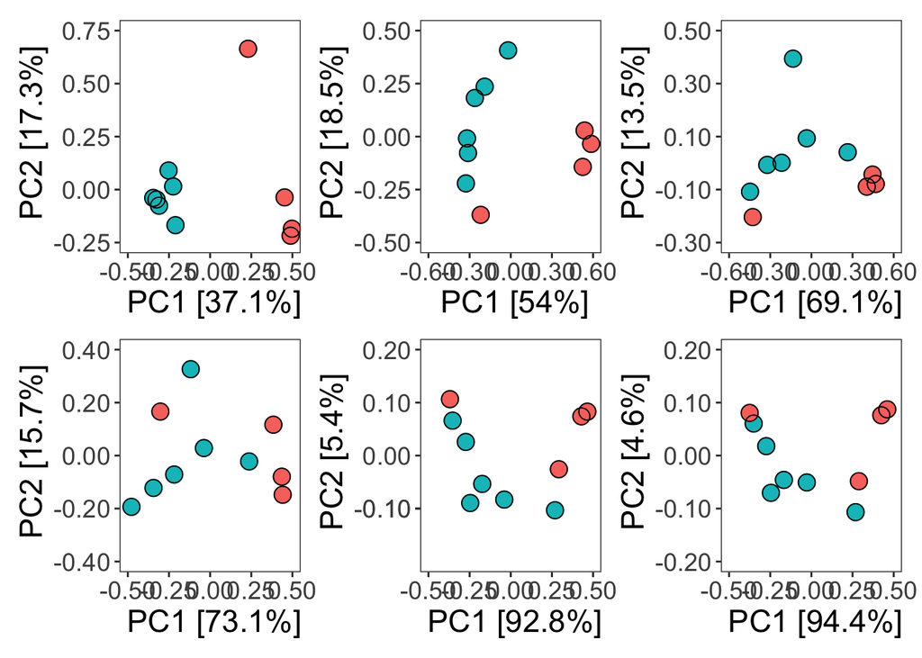

```r
p.beta.sp + p.beta.genus + p.beta.fam + p.beta.order + p.beta.class + p.beta.phylum
```

```r
pdf('Standard.beta.pdf', width=9, height=5)
p.beta.sp + p.beta.genus + p.beta.fam + p.beta.order + p.beta.class + p.beta.phylum
dev.off()
```

## Compare taxon abundance in the standard data

Summarize the most abundant taxa at the phylum level in the mealworms and superworms in the standard diets.

```r
# Agglomerate data at phylum level
ps.rel.phylum <- tax_glom(ps.rel, "Phylum", NArm = FALSE)

# Create a dataframe from phyloseq object
ps.rel.phylum.df <- psmelt(ps.rel.phylum)

# Get summary statistics
df <- ps.rel.phylum.df %>%
  group_by(Insect, Phylum) %>%
  summarize(mean = mean(Abundance, na.rm = TRUE),
            median = median(Abundance, na.rm = TRUE),
            stdev = sd(Abundance, na.rm = TRUE),
            counts = n(),
            se = stdev / sqrt(counts))

# Create a table rounded to 1 decimal place
df.w <- df %>%
  mutate(stat = paste0(round(100 * mean, 1), " +/- ", round(100 * stdev, 1))) %>%
  select(Insect, Phylum, stat) %>%
  pivot_wider(
    names_from = Insect,
    values_from = stat
  )
kable(df.w, digits = 1, align = "l",
      caption = "test") %>%
  kable_classic(full_width = FALSE)
```

test

| Phylum | Mealworm | Superworm |
| --- | --- | --- |
| Actinomycetota | 2.9 +/- 5.7 | 0.6 +/- 0.5 |
| Bacillota | 39.4 +/- 39.1 | 69.9 +/- 22.7 |
| Bacteroidota | 0 +/- 0 | 4 +/- 2.9 |
| Fusobacteriota | 0 +/- 0 | 0.5 +/- 0.4 |
| Pseudomonadota | 57.7 +/- 38.7 | 25 +/- 20.4 |

```r
# Create a table rounded to 6 decimal place
df.w <- df %>%
  mutate(stat = paste0(round(100 * mean, 6), " +/- ", round(100 * stdev, 6))) %>%
  select(Insect, Phylum, stat) %>%
  pivot_wider(
    names_from = Insect,
    values_from = stat
  )
kable(df.w, digits = 6, align = "l",
      caption = "test") %>%
  kable_classic(full_width = FALSE)
```

test

| Phylum | Mealworm | Superworm |
| --- | --- | --- |
| Actinomycetota | 2.938006 +/- 5.746349 | 0.584051 +/- 0.512541 |
| Bacillota | 39.358162 +/- 39.146977 | 69.926555 +/- 22.696061 |
| Bacteroidota | 1e-06 +/- 2e-06 | 4.007498 +/- 2.86005 |
| Fusobacteriota | 0 +/- 0 | 0.462348 +/- 0.389987 |
| Pseudomonadota | 57.703831 +/- 38.656096 | 25.019547 +/- 20.38401 |

Summarize the most abundant taxa at the order level in the mealworms and superworms in the standard diets for the 10 most abundant orders.

```r
# Agglomerate data at order level
ps.rel.order <- tax_glom(ps.rel, "Order", NArm = FALSE)

# Identify the most abundant orders
top.taxa = names(sort(taxa_sums(ps.rel.order), TRUE)[1:10])
top.taxa.table = cbind(tax_table(ps.rel.order), topTaxa = NA)
top.taxa.table[top.taxa, "topTaxa"] <- as(tax_table(ps.rel.order)[top.taxa, "Order"],
                                          "character")
tax_table(ps.rel.order) <- tax_table(top.taxa.table)

# Create a dataframe from phyloseq object
ps.rel.order.df <- psmelt(ps.rel.order)
ps.rel.order.df$Order <- as.character(ps.rel.order.df$Order) #convert to character
ps.rel.order.df.noNA <- na.omit(ps.rel.order.df)
ps.rel.order.df <- ps.rel.order.df.noNA

# Get summary statistics
df <- ps.rel.order.df %>%
  group_by(Insect, Order) %>%
  summarize(mean = mean(Abundance, na.rm = TRUE),
            median = median(Abundance, na.rm = TRUE),
            stdev = sd(Abundance, na.rm = TRUE),
            counts = n(),
            se = stdev / sqrt(counts))

# Create a table rounded to 1 decimal place
df.w <- df %>%
  mutate(stat = paste0(round(100 * mean, 1), " +/- ", round(100 * stdev, 1))) %>%
  select(Insect, Order, stat) %>%
  pivot_wider(
    names_from = Insect,
    values_from = stat
  )
kable(df.w, digits = 1, align = "l",
      caption = "test") %>%
  kable_classic(full_width = FALSE)
```

test

| Order | Mealworm | Superworm |
| --- | --- | --- |
| Bacillales | 1.5 +/- 3 | 0 +/- 0 |
| Bacteroidales | 0 +/- 0 | 2.3 +/- 2.1 |
| Burkholderiales | 0 +/- 0 | 1 +/- 0.8 |
| Enterobacterales | 57.7 +/- 38.7 | 21.4 +/- 16.6 |
| Flavobacteriales | 0 +/- 0 | 1.6 +/- 1.6 |
| Lactobacillales | 20.9 +/- 7 | 20.5 +/- 20.1 |
| Mycobacteriales | 2.3 +/- 4.5 | 0.6 +/- 0.5 |
| Mycoplasmatales | 12.7 +/- 24.6 | 47.9 +/- 28.7 |
| Pseudomonadales | 0 +/- 0 | 2.6 +/- 4 |
| Staphylococcales | 4.2 +/- 6.6 | 0 +/- 0 |

```r
# Create a table rounded to 6 decimal place
df.w <- df %>%
  mutate(stat = paste0(round(100 * mean, 6), " +/- ", round(100 * stdev, 6))) %>%
  select(Insect, Order, stat) %>%
  pivot_wider(
    names_from = Insect,
    values_from = stat
  )
kable(df.w, digits = 6, align = "l",
      caption = "test") %>%
  kable_classic(full_width = FALSE)
```

test

| Order | Mealworm | Superworm |
| --- | --- | --- |
| Bacillales | 1.493376 +/- 2.986661 | 0 +/- 0 |
| Bacteroidales | 1e-06 +/- 2e-06 | 2.348674 +/- 2.117967 |
| Burkholderiales | 0 +/- 0 | 1.005751 +/- 0.836469 |
| Enterobacterales | 57.703831 +/- 38.656096 | 21.393813 +/- 16.648862 |
| Flavobacteriales | 0 +/- 0 | 1.626981 +/- 1.590591 |
| Lactobacillales | 20.943109 +/- 7.040961 | 20.524162 +/- 20.10669 |
| Mycobacteriales | 2.299076 +/- 4.517055 | 0.584051 +/- 0.512541 |
| Mycoplasmatales | 12.702257 +/- 24.60126 | 47.901242 +/- 28.665457 |
| Pseudomonadales | 0 +/- 0 | 2.619654 +/- 4.037195 |
| Staphylococcales | 4.219398 +/- 6.569486 | 0.012141 +/- 0.010759 |

Summarize the most abundant taxa at the genus level in the mealworms and superworms in the standard diets for the 40 most abundant genera

```r
# Agglomerate data at genus level
ps.rel.genus <- tax_glom(ps.rel, "Genus", NArm = FALSE)

# Identify the most abundant orders
top.taxa = names(sort(taxa_sums(ps.rel.genus), TRUE)[1:40])
top.taxa.table = cbind(tax_table(ps.rel.genus), topTaxa = NA)
top.taxa.table[top.taxa, "topTaxa"] <- as(tax_table(ps.rel.genus)[top.taxa, "Genus"],
                                          "character")
tax_table(ps.rel.genus) <- tax_table(top.taxa.table)

# Create a dataframe from phyloseq object
ps.rel.genus.df <- psmelt(ps.rel.genus)
ps.rel.genus.df$Genus <- as.character(ps.rel.genus.df$Genus) #convert to character
ps.rel.genus.df.noNA <- na.omit(ps.rel.genus.df)
ps.rel.genus.df <- ps.rel.genus.df.noNA

# Get summary statistics
df <- ps.rel.genus.df %>%
  group_by(Insect, Genus) %>%
  summarize(mean = mean(Abundance, na.rm = TRUE),
            median = median(Abundance, na.rm = TRUE),
            stdev = sd(Abundance, na.rm = TRUE),
            counts = n(),
            se = stdev / sqrt(counts))

# Create a table rounded to 1 decimal place
df.w <- df %>%
  mutate(stat = paste0(round(100 * mean, 1), " +/- ", round(100 * stdev, 1))) %>%
  select(Insect, Genus, stat) %>%
  pivot_wider(
    names_from = Insect,
    values_from = stat
  )
kable(df.w, digits = 1, align = "l",
      caption = "test") %>%
  kable_classic(full_width = FALSE)
```

test

| Genus | Mealworm | Superworm |
| --- | --- | --- |
| Apibacter | 0 +/- 0 | 1 +/- 0.7 |
| Brevibacterium | 0.5 +/- 1 | 0 +/- 0 |
| CALYQQ01 | 0 +/- 0 | 1.6 +/- 0.5 |
| Chryseobacterium | 0 +/- 0 | 0.7 +/- 1.1 |
| Citrobacter | 0 +/- 0 | 1.3 +/- 1.7 |
| Citrobacter_B | 0 +/- 0 | 5.1 +/- 5.8 |
| Corynebacterium | 2.3 +/- 4.5 | 0.6 +/- 0.5 |
| DAIDKD01 | 1.5 +/- 3 | 0 +/- 0 |
| Dysgonomonas | 0 +/- 0 | 2.3 +/- 2.1 |
| Enterobacter | 4.2 +/- 5.3 | 0.6 +/- 0.4 |
| Enterococcus | 3.6 +/- 3.5 | 1.2 +/- 0.9 |
| Enterococcus_A | 0 +/- 0 | 2.2 +/- 1.5 |
| Enterococcus_B | 3.1 +/- 2.4 | 0.3 +/- 0.7 |
| Enterococcus_C | 0 +/- 0 | 1.3 +/- 2 |
| Enterococcus_D | 0.6 +/- 1 | 1.7 +/- 1.4 |
| Enterococcus_J | 0 +/- 0 | 0.3 +/- 0.5 |
| Entomomonas | 0 +/- 0 | 2.3 +/- 4.2 |
| Hafnia | 0 +/- 0 | 0.7 +/- 1.7 |
| Intestinirhabdus | 13 +/- 13.9 | 1.4 +/- 2.9 |
| JAGNPU01 | 0 +/- 0 | 0.8 +/- 0.6 |
| JALAGN01 | 12.7 +/- 24.6 | 47.9 +/- 28.7 |
| Jejubacter | 16.1 +/- 16.7 | 0 +/- 0 |
| Klebsiella | 0.1 +/- 0.1 | 5 +/- 5.5 |
| Kluyvera | 0.1 +/- 0 | 4.8 +/- 3.2 |
| Lactococcus | 2.9 +/- 2.2 | 11.8 +/- 18.3 |
| Lactococcus_A | 0 +/- 0 | 0.3 +/- 0.3 |
| Latilactobacillus | 7.7 +/- 10.7 | 0 +/- 0 |
| Listeria | 2 +/- 3.2 | 0 +/- 0 |
| Mammaliicoccus | 0.6 +/- 1.1 | 0 +/- 0 |
| Merdenecus | 0 +/- 0 | 0.5 +/- 0.4 |
| Mixta | 4 +/- 6.9 | 0.4 +/- 0.5 |
| Morganella | 0 +/- 0 | 0.3 +/- 0.6 |
| Pediococcus | 0 +/- 0.1 | 1.3 +/- 1.4 |
| Romboutsia_A | 0 +/- 0 | 0.2 +/- 0.4 |
| Scandinavium | 0 +/- 0 | 0.2 +/- 0.2 |
| Sebaldella | 0 +/- 0 | 0.5 +/- 0.4 |
| Staphylococcus | 3.7 +/- 6.7 | 0 +/- 0 |
| Tenebrionibacter | 20.3 +/- 21.6 | 0 +/- 0 |
| Weissella | 1.1 +/- 1.7 | 0.1 +/- 0.1 |

```r
# Create a table rounded to 6 decimal place
df.w <- df %>%
  mutate(stat = paste0(round(100 * mean, 6), " +/- ", round(100 * stdev, 6))) %>%
  select(Insect, Genus, stat) %>%
  pivot_wider(
    names_from = Insect,
    values_from = stat
  )
kable(df.w, digits = 6, align = "l",
      caption = "test") %>%
  kable_classic(full_width = FALSE)
```

test

| Genus | Mealworm | Superworm |
| --- | --- | --- |
| Apibacter | 0 +/- 0 | 0.962938 +/- 0.728057 |
| Brevibacterium | 0.520044 +/- 1.020541 | 0 +/- 0 |
| CALYQQ01 | 0 +/- 0 | 1.573391 +/- 0.476119 |
| Chryseobacterium | 0 +/- 0 | 0.663658 +/- 1.098591 |
| Citrobacter | 0 +/- 0 | 1.341925 +/- 1.701913 |
| Citrobacter_B | 0 +/- 0 | 5.11175 +/- 5.757241 |
| Corynebacterium | 2.299076 +/- 4.517055 | 0.584051 +/- 0.512541 |
| DAIDKD01 | 1.493376 +/- 2.986661 | 0 +/- 0 |
| Dysgonomonas | 1e-06 +/- 2e-06 | 2.348674 +/- 2.117967 |
| Enterobacter | 4.197195 +/- 5.280451 | 0.624538 +/- 0.412373 |
| Enterococcus | 3.610999 +/- 3.528143 | 1.164979 +/- 0.88241 |
| Enterococcus_A | 0.011274 +/- 0.005466 | 2.160935 +/- 1.502363 |
| Enterococcus_B | 3.051588 +/- 2.427079 | 0.330626 +/- 0.689575 |
| Enterococcus_C | 0.001603 +/- 0.000982 | 1.293473 +/- 1.977198 |
| Enterococcus_D | 0.640926 +/- 1.037243 | 1.733104 +/- 1.390879 |
| Enterococcus_J | 0 +/- 0 | 0.253847 +/- 0.474916 |
| Entomomonas | 0 +/- 0 | 2.343812 +/- 4.16122 |
| Hafnia | 0 +/- 0 | 0.690613 +/- 1.684876 |
| Intestinirhabdus | 12.998548 +/- 13.922218 | 1.362736 +/- 2.94681 |
| JAGNPU01 | 0 +/- 0 | 0.838847 +/- 0.560173 |
| JALAGN01 | 12.702257 +/- 24.60126 | 47.901242 +/- 28.665457 |
| Jejubacter | 16.089547 +/- 16.679905 | 0 +/- 0 |
| Klebsiella | 0.061604 +/- 0.058638 | 5.021314 +/- 5.472103 |
| Kluyvera | 0.057673 +/- 0.038339 | 4.762702 +/- 3.191466 |
| Lactococcus | 2.867868 +/- 2.193052 | 11.757646 +/- 18.297965 |
| Lactococcus_A | 0 +/- 0 | 0.278644 +/- 0.299644 |
| Latilactobacillus | 7.715063 +/- 10.656942 | 0 +/- 0 |
| Listeria | 1.952011 +/- 3.187396 | 0 +/- 0 |
| Mammaliicoccus | 0.564031 +/- 1.073917 | 0 +/- 0 |
| Merdenecus | 0 +/- 0 | 0.521342 +/- 0.399057 |
| Mixta | 3.957116 +/- 6.923892 | 0.421037 +/- 0.485439 |
| Morganella | 0 +/- 0 | 0.261298 +/- 0.623858 |
| Pediococcus | 0.035616 +/- 0.062071 | 1.269536 +/- 1.398539 |
| Romboutsia_A | 2.1e-05 +/- 3.9e-05 | 0.218596 +/- 0.418125 |
| Scandinavium | 0 +/- 0 | 0.201335 +/- 0.169372 |
| Sebaldella | 0 +/- 0 | 0.462348 +/- 0.389987 |
| Staphylococcus | 3.655367 +/- 6.747631 | 0.012141 +/- 0.010759 |
| Tenebrionibacter | 20.342147 +/- 21.574858 | 0 +/- 0 |
| Weissella | 1.05008 +/- 1.715105 | 0.086332 +/- 0.113264 |

## Clean the workspace to switch to mealworm data

```r
rm(list = ls())
```

# Analyse of the mealworm data across treatments

## Prepare a phyloseq object for the mealworm data

Use the MAG abundance data and the GTDB-Tk output data to generate a phyloseq object.

```r
# Load the OTU table
otumat <- as.matrix(read.table("mealworm_MAG_abundances_depth.txt",
                        header = TRUE, row.names = 1))

# Load the taxonomy table
taxmat <- as.matrix(read.table("mealworm_MAG_taxonomy.txt",
                        header = TRUE, row.names = 1))

# Load the sample metadata
metadata <- read.table("mealworm_sample_metadata.txt",
                       header = TRUE, row.names = 1)

# Combine the data into a phyloseq object
OTU <- otu_table(otumat, taxa_are_rows = TRUE)
TAX <- tax_table(taxmat)
META <- sample_data(metadata)
ps <- phyloseq(OTU, TAX, META)

# Convert MAG abundances to percentages
ps.rel <- transform_sample_counts(ps, function(x) x / sum(x))
```

## Calculate alpha-diversity for the mealworm data and perform statistical analysis

Calculate Shannon and Simpson’s diversity metrics and test if the values are statistically different between samples. Include insect batch and replicate as random effects, with replicate nested within batch.

```r
# Calculate alpha-diversity metrics
richness <- estimate_richness(ps.rel, measures = c("Shannon", "Simpson"))

# Add columns with relevant metadata
richness$treatment <- metadata$Treatment
richness$replicate <- metadata$Replicate
richness$batch <- metadata$Insect_batch

# Create factors for treatment, ordering the treatments as desired
richness$treatment <- factor(richness$treatment,
                                 levels = c("Standard", "Polyethylene", "Polystyrene", "Starvation"))

# Perform statistical analysis on the Shannon data
model.shannon <- lmer(log(Shannon) ~ treatment + (1 | batch/replicate), data=richness)
summary(model.shannon)
```

```
## Linear mixed model fit by REML ['lmerMod']
## Formula: log(Shannon) ~ treatment + (1 | batch/replicate)
##    Data: richness
##
## REML criterion at convergence: 1.2
##
## Scaled residuals:
##     Min      1Q  Median      3Q     Max
## -1.4481 -0.5208 -0.1816  0.6246  1.4870
##
## Random effects:
##  Groups          Name        Variance Std.Dev.
##  replicate:batch (Intercept) 0.003817 0.06178
##  batch           (Intercept) 0.060879 0.24674
##  Residual                    0.029609 0.17207
## Number of obs: 22, groups:  replicate:batch, 6; batch, 3
##
## Fixed effects:
##                       Estimate Std. Error t value
## (Intercept)             0.6359     0.1693   3.755
## treatmentPolyethylene   0.1333     0.1126   1.184
## treatmentPolystyrene   -0.0523     0.1126  -0.464
## treatmentStarvation     0.2743     0.1126   2.436
##
## Correlation of Fixed Effects:
##             (Intr) trtmntPlyt trtmntPlys
## trtmntPlyth -0.406
## trtmntPlyst -0.406  0.611
## trtmntStrvt -0.406  0.611      0.611
```

```r
model.shannon.aov <- Anova(model.shannon, type = 2)
model.shannon.em <- emmeans(model.shannon, pairwise ~ treatment,
                            infer = TRUE, type = "response")
model.shannon.em$emmeans
```

```
##  treatment    response    SE   df lower.CL upper.CL null t.ratio p.value
##  Standard         1.89 0.324 3.27     1.12     3.18    1   3.711  0.0294
##  Polyethylene     2.16 0.347 2.68     1.25     3.73    1   4.783  0.0224
##  Polystyrene      1.79 0.288 2.68     1.04     3.10    1   3.629  0.0433
##  Starvation       2.48 0.400 2.68     1.44     4.30    1   5.660  0.0147
##
## Degrees-of-freedom method: kenward-roger
## Confidence level used: 0.95
## Intervals are back-transformed from the log scale
## Tests are performed on the log scale
```

```r
model.shannon.em$contrasts
```

```
##  contrast                   ratio     SE   df lower.CL upper.CL null t.ratio p.value
##  Standard / Polyethylene    0.875 0.1010 13.9    0.625    1.225    1  -1.153  0.6645
##  Standard / Polystyrene     1.054 0.1220 13.9    0.753    1.475    1   0.452  0.9681
##  Standard / Starvation      0.760 0.0879 13.9    0.543    1.064    1  -2.373  0.1288
##  Polyethylene / Polystyrene 1.204 0.1200 13.0    0.899    1.611    1   1.868  0.2877
##  Polyethylene / Starvation  0.868 0.0863 13.0    0.649    1.162    1  -1.420  0.5098
##  Polystyrene / Starvation   0.721 0.0717 13.0    0.539    0.966    1  -3.288  0.0264
##
## Degrees-of-freedom method: kenward-roger
## Confidence level used: 0.95
## Conf-level adjustment: tukey method for comparing a family of 4 estimates
## Intervals are back-transformed from the log scale
## P value adjustment: tukey method for comparing a family of 4 estimates
## Tests are performed on the log scale
```

```r
# Perform statistical analysis on the Simpson data
model.simpson <- lmer(log(Simpson) ~ treatment + (1 | batch/replicate), data=richness)
summary(model.simpson)
```

```
## Linear mixed model fit by REML ['lmerMod']
## Formula: log(Simpson) ~ treatment + (1 | batch/replicate)
##    Data: richness
##
## REML criterion at convergence: -4
##
## Scaled residuals:
##      Min       1Q   Median       3Q      Max
## -1.29188 -0.52680 -0.01233  0.81738  1.45600
##
## Random effects:
##  Groups          Name        Variance Std.Dev.
##  replicate:batch (Intercept) 0.004522 0.06724
##  batch           (Intercept) 0.043480 0.20852
##  Residual                    0.021579 0.14690
## Number of obs: 22, groups:  replicate:batch, 6; batch, 3
##
## Fixed effects:
##                       Estimate Std. Error t value
## (Intercept)           -0.29465    0.14473  -2.036
## treatmentPolyethylene  0.01182    0.09641   0.123
## treatmentPolystyrene  -0.13470    0.09641  -1.397
## treatmentStarvation    0.13073    0.09641   1.356
##
## Correlation of Fixed Effects:
##             (Intr) trtmntPlyt trtmntPlys
## trtmntPlyth -0.408
## trtmntPlyst -0.408  0.613
## trtmntStrvt -0.408  0.613      0.613
```

```r
model.simpson.aov <- Anova(model.simpson, type = 2)
model.simpson.em <- emmeans(model.simpson, pairwise ~ treatment,
                            infer = TRUE, type = "response")
model.simpson.em$emmeans
```

```
##  treatment    response     SE   df lower.CL upper.CL null t.ratio p.value
##  Standard        0.745 0.1090 3.28    0.478     1.16    1  -2.015  0.1294
##  Polyethylene    0.754 0.1030 2.68    0.472     1.20    1  -2.060  0.1423
##  Polystyrene     0.651 0.0894 2.68    0.408     1.04    1  -3.128  0.0607
##  Starvation      0.849 0.1170 2.68    0.532     1.36    1  -1.194  0.3274
##
## Degrees-of-freedom method: kenward-roger
## Confidence level used: 0.95
## Intervals are back-transformed from the log scale
## Tests are performed on the log scale
```

```r
model.simpson.em$contrasts
```

```
##  contrast                   ratio     SE   df lower.CL upper.CL null t.ratio p.value
##  Standard / Polyethylene    0.988 0.0975 13.8    0.741    1.317    1  -0.120  0.9994
##  Standard / Polystyrene     1.144 0.1130 13.8    0.858    1.525    1   1.366  0.5397
##  Standard / Starvation      0.877 0.0865 13.8    0.658    1.170    1  -1.325  0.5631
##  Polyethylene / Polystyrene 1.158 0.0982 13.0    0.903    1.485    1   1.728  0.3493
##  Polyethylene / Starvation  0.888 0.0753 13.0    0.692    1.139    1  -1.402  0.5198
##  Polystyrene / Starvation   0.767 0.0650 13.0    0.598    0.984    1  -3.130  0.0352
##
## Degrees-of-freedom method: kenward-roger
## Confidence level used: 0.95
## Conf-level adjustment: tukey method for comparing a family of 4 estimates
## Intervals are back-transformed from the log scale
## P value adjustment: tukey method for comparing a family of 4 estimates
## Tests are performed on the log scale
```

## Plot the alpha-diversity metrics for the mealworm samples

Generate plots showing the Shannon and Simpson’s diversity metrics

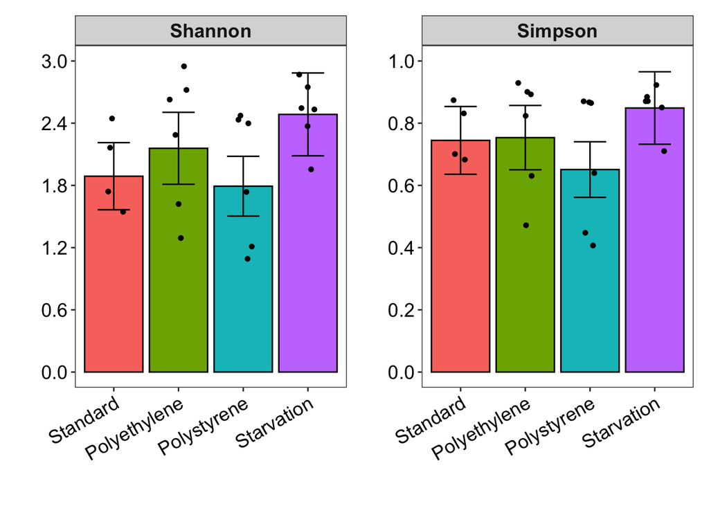

```r
# Collect the emmeans for Shannon data
emms.shannon <- as.data.frame(model.shannon.em$emmeans)
emms.shannon$metric <- 'Shannon'

# Collect the emmeans for teh Simpson's data
emms.simpson <- as.data.frame(model.simpson.em$emmeans)
emms.simpson$metric <- 'Simpson'

# Plot the Shannon data
p.shannon <- ggplot() +
  geom_bar(data = emms.shannon,
           aes(x = treatment, y = response, fill = treatment),
           stat = "identity",
           colour = "black") +
  geom_errorbar(data = emms.shannon,
                aes(x = treatment, ymin = response-SE, ymax = response+SE),
                stat = "identity", width = 0.5, size = 0.5) +
  geom_jitter(data = richness,
              aes(x = treatment, y = Shannon),
              width = 0.15, size = 1.25) +
  facet_wrap(~metric, scales="free_y") +
  theme_bw() +
  theme(text = element_text(size = 17), legend.position = "none",
        panel.grid.major = element_blank(),
        panel.grid.minor = element_blank(),
        strip.text.x = element_text(face="bold"),
        axis.text.x = element_text(angle = 30, vjust = 1, hjust = 1, color="black"),
        axis.text.y = element_text(color="black")) +
  scale_y_continuous(lim=c(0,3), breaks=c(0.0,0.6,1.2,1.8,2.4,3.0)) +
  xlab("") + ylab("")

# Plot the Simpson's data
p.simpson <- ggplot() +
  geom_bar(data = emms.simpson,
           aes(x = treatment, y = response, fill = treatment),
           stat = "identity",
           colour = "black") +
  geom_errorbar(data = emms.simpson,
                aes(x = treatment, ymin = response-SE, ymax = response+SE),
                stat = "identity", width = 0.5, size = 0.5) +
  geom_jitter(data = richness,
              aes(x = treatment, y = Simpson),
              width = 0.15, size = 1.25) +
  facet_wrap(~metric, scales="free_y") +
  theme_bw() +
  theme(text = element_text(size = 17), legend.position = "none",
        panel.grid.major = element_blank(),
        panel.grid.minor = element_blank(),
        strip.text.x = element_text(face="bold"),
        axis.text.x = element_text(angle = 30, vjust = 1, hjust = 1, color="black"),
        axis.text.y = element_text(color="black")) +
  scale_y_continuous(lim=c(0,1), breaks=c(0.0,0.2,0.4,0.6,0.8,1.0)) +
  xlab("") + ylab("")

# Combine the plots as two panels in one figure
p.shannon + p.simpson
```

```r
# Export a PDF of the figure
pdf('Mealworm.alpha.pdf', width=10, height=5)
p.shannon + p.simpson
dev.off()
```

## Calculate and plot beta-diversity for the mealworm data and perform statistical analysis

```r
# Calculate the bray curtis distances
dist_bc <- phyloseq::distance(ps.rel, method = "bray")

# Extract sample data
meta <- data.frame(sample_data(ps.rel))

# Perform a permutation test to test if the data meet the assumptions of PERMANOVA
beta.bray <- betadisper(dist_bc, meta$Treatment, type = "centroid", bias.adjust = TRUE)
permdisp <- permutest(beta.bray, pairwise = TRUE, permutations = 10000)
permdisp
```

```
##
## Permutation test for homogeneity of multivariate dispersions
## Permutation: free
## Number of permutations: 10000
##
## Response: Distances
##           Df  Sum Sq  Mean Sq      F N.Perm Pr(>F)
## Groups     3 0.13078 0.043593 5.6005  10000 0.0043 **
## Residuals 18 0.14011 0.007784
## ---
## Signif. codes:  0 '***' 0.001 '**' 0.01 '*' 0.05 '.' 0.1 ' ' 1
##
## Pairwise comparisons:
## (Observed p-value below diagonal, permuted p-value above diagonal)
##              Polyethylene Polystyrene Standard Starvation
## Polyethylene                 0.548545 0.043796     0.0548
## Polystyrene      0.502756             0.028297     0.2459
## Standard         0.059182    0.036783              0.0091
## Starvation       0.069541    0.242129 0.011910
```

The dispersion is significantly different between samples, which means the results of PERMANOVA are not reliable. Nevertheless, run the PERMANOVA (accounting for treatment and batch) and pair it with a PCoA to visualize the data.

```r
# Run the PERMANOVA test
adonis.bray <- adonis2(dist_bc ~ Treatment + Insect_batch, data = meta, permutations = 10000, by = "terms")
as.data.frame(adonis.bray)
```

```
##              Df  SumOfSqs        R2        F     Pr(>F)
## Treatment     3 0.8356470 0.2308665 2.366646 0.00869913
## Insect_batch  2 0.9007996 0.2488664 3.826748 0.00089991
## Residual     16 1.8831645 0.5202671       NA         NA
## Total        21 3.6196111 1.0000000       NA         NA
```

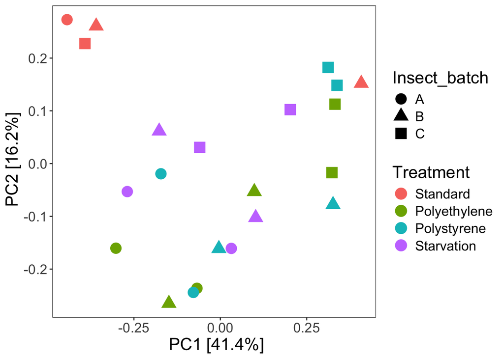

```r
# Create a PCoA plot
sample_data(ps.rel)$Treatment <- factor(sample_data(ps.rel)$Treatment,
                                        levels = c("Standard", "Polyethylene", "Polystyrene", "Starvation"))
pso <- ordinate(ps.rel, "PCoA", "bray")
var_explained <- pso$values$Relative_eig * 100
ordplot5 <- plot_ordination(ps.rel, pso, type="samples",
                            color="Treatment", shape="Insect_batch",
                            axes = c(1,2))
p.beta.pcoa <- ordplot5 +  theme_bw() + theme(text = element_text(size = 17), aspect.ratio = 1) +
  geom_point(size = 5) +
  theme_bw() +
  theme(text = element_text(size = 17),
        panel.grid.major = element_blank(),
        panel.grid.minor = element_blank(),
        legend.position = "right") +
  labs(x = paste0(" PC1 [", round(var_explained[1], 1), "%]"),
       y = paste0(" PC2 [", round(var_explained[2], 1), "%]"))
p.beta.pcoa
```

```r
# Save the figure
pdf('Mealworm.beta.pcoa.pdf', width=10, height=5)
p.beta.pcoa
dev.off()
```

Now run a capscale analysis since it is less sensitive to differences in dispersion and thus should be more appropriate than PERMANOVA in this case.

```r
# Set the formula for the model
class(fo <- dist_bc ~ meta$Treatment + meta$Insect_batch)
```

```
## [1] "formula"
```

```r
# Run the capscale analysis followed by an ANOVA
pso_cap <- ordinate(ps.rel, "CAP", "bray", formula=fo)
anova(pso_cap, by = "terms", type = 2)
```

```
## Permutation test for capscale under reduced model
## Terms added sequentially (first to last)
## Permutation: free
## Number of permutations: 999
##
## Model: capscale(formula = OTU ~ meta$Treatment + meta$Insect_batch, data = data, distance = distance)
##                   Df SumOfSqs      F Pr(>F)
## meta$Treatment     3  0.85023 2.2429  0.007 **
## meta$Insect_batch  2  0.90533 3.5824  0.003 **
## Residual          16  2.02175
## ---
## Signif. codes:  0 '***' 0.001 '**' 0.01 '*' 0.05 '.' 0.1 ' ' 1
```

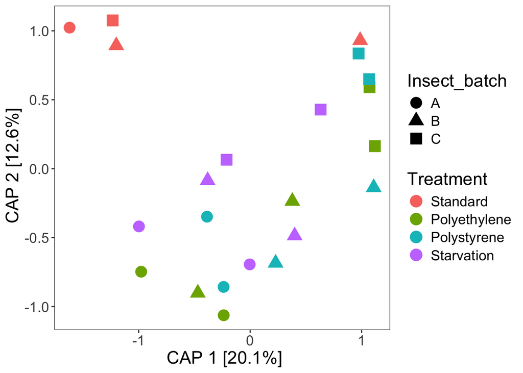

```r
# Get the relative eigenvalues
all_eig <- eigenvals(pso_cap)
rel_eig <- all_eig / sum(all_eig)
var_explained <- round(rel_eig * 100, 1)

# Plot the capscale results
ordplot5 <- plot_ordination(ps.rel, pso_cap, type="samples", color="Treatment",
                            shape="Insect_batch", axes = c(1,2))
p.beta.cap <- ordplot5 +  theme_bw() + theme(text = element_text(size = 17), aspect.ratio = 1) +
  geom_point(size = 5) +
  theme_bw() +
  theme(text = element_text(size = 17),
        panel.grid.major = element_blank(),
        panel.grid.minor = element_blank(),
        legend.position = "right") +
  labs(x = paste0(" CAP 1 [", round(var_explained[1], 1), "%]"),
       y = paste0(" CAP 2 [", round(var_explained[2], 1), "%]"))
p.beta.cap
```

```r
# Save the figure
pdf('Mealworm.beta.cap.pdf', width=10, height=5)
p.beta.pcoa
dev.off()
```

To mimic what will be done for the superworm data, see what the PCoA and CAP plots look like if summarized at the genus level

```r
# Summarize at the genus level, removing taxa not classified at the genus level
ps.rel.genus <- tax_glom(ps.rel, "Genus", NArm = TRUE)

# Calculate the bray curtis distances
dist_bc <- phyloseq::distance(ps.rel.genus, method = "bray")

# Extract sample data
meta <- data.frame(sample_data(ps.rel.genus))

# Perform a permutation test to test if the data meet the assumptions of PERMANOVA
beta.bray <- betadisper(dist_bc, meta$Treatment, type = "centroid", bias.adjust = TRUE)
permdisp <- permutest(beta.bray, pairwise = TRUE, permutations = 10000)
permdisp
```

```
##
## Permutation test for homogeneity of multivariate dispersions
## Permutation: free
## Number of permutations: 10000
##
## Response: Distances
##           Df  Sum Sq  Mean Sq      F N.Perm Pr(>F)
## Groups     3 0.16242 0.054141 6.1243  10000 0.0037 **
## Residuals 18 0.15912 0.008840
## ---
## Signif. codes:  0 '***' 0.001 '**' 0.01 '*' 0.05 '.' 0.1 ' ' 1
##
## Pairwise comparisons:
## (Observed p-value below diagonal, permuted p-value above diagonal)
##              Standard Polyethylene Polystyrene Starvation
## Standard                  0.027197    0.025497     0.0062
## Polyethylene 0.041019                 0.928807     0.0780
## Polystyrene  0.036024     0.917809                 0.0852
## Starvation   0.010228     0.094030    0.103670
```

```r
# Run the PERMANOVA test
adonis.bray <- adonis2(dist_bc ~ Treatment + Insect_batch, data = meta, permutations = 10000, by = "terms")
as.data.frame(adonis.bray)
```

```
##              Df  SumOfSqs        R2        F     Pr(>F)
## Treatment     3 0.6491472 0.2048475 2.009214 0.03389661
## Insect_batch  2 0.7966616 0.2513977 3.698693 0.00119988
## Residual     16 1.7231205 0.5437548       NA         NA
## Total        21 3.1689293 1.0000000       NA         NA
```

```r
# Create a PCoA plot
pso <- ordinate(ps.rel.genus, "PCoA", "bray")
var_explained <- pso$values$Relative_eig * 100
ordplot5 <- plot_ordination(ps.rel.genus, pso, type="samples",
                            color="Treatment", shape="Insect_batch",
                            axes = c(1,2))
p.beta.pcoa.genus <- ordplot5 + theme_bw() +
  theme(text = element_text(size = 17), aspect.ratio = 1) +
  geom_point(size = 5) +
  theme_bw() +
  theme(text = element_text(size = 17),
        panel.grid.major = element_blank(),
        panel.grid.minor = element_blank(),
        legend.position = "none") +
  labs(x = paste0(" PC1 [", round(var_explained[1], 1), "%]"),
       y = paste0(" PC2 [", round(var_explained[2], 1), "%]"))

# Set the formula for the model for the capscale analysis
class(fo <- dist_bc ~ meta$Treatment + meta$Insect_batch)
```

```
## [1] "formula"
```

```r
# Run the capscale analysis followed by an ANOVA
pso_cap <- ordinate(ps.rel.genus, "CAP", "bray", formula=fo)
anova(pso_cap, by = "terms", type = 2)
```

```
## Permutation test for capscale under reduced model
## Terms added sequentially (first to last)
## Permutation: free
## Number of permutations: 999
##
## Model: capscale(formula = OTU ~ meta$Treatment + meta$Insect_batch, data = data, distance = distance)
##                   Df SumOfSqs      F Pr(>F)
## meta$Treatment     3  0.67341 1.8802  0.042 *
## meta$Insect_batch  2  0.80817 3.3848  0.002 **
## Residual          16  1.91014
## ---
## Signif. codes:  0 '***' 0.001 '**' 0.01 '*' 0.05 '.' 0.1 ' ' 1
```

```r
# Get the relative eigenvalues
all_eig <- eigenvals(pso_cap)
rel_eig <- all_eig / sum(all_eig)
var_explained <- round(rel_eig * 100, 1)

# Plot the capscale results
ordplot5 <- plot_ordination(ps.rel.genus, pso_cap, type="samples", color="Treatment",
                            shape="Insect_batch", axes = c(1,2))
p.beta.cap.genus <- ordplot5 + theme_bw() +
  theme(text = element_text(size = 17), aspect.ratio = 1) +
  geom_point(size = 5) +
  theme_bw() +
  theme(text = element_text(size = 17),
        panel.grid.major = element_blank(),
        panel.grid.minor = element_blank(),
        legend.position = "none") +
  labs(x = paste0(" CAP 1 [", round(var_explained[1], 1), "%]"),
       y = paste0(" CAP 2 [", round(var_explained[2], 1), "%]"))
```

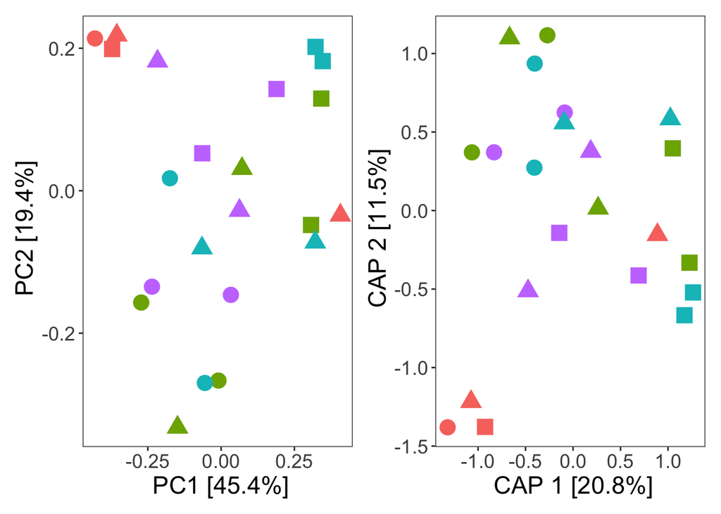

```r
# Display both graphs
p.beta.pcoa.genus + p.beta.cap.genus
```

```r
# Save the figure
pdf('Mealworm.beta.genus.pdf', width=10, height=5)
p.beta.pcoa.genus + p.beta.cap.genus
dev.off()
```

## Compare taxon abundance in the mealworm data

Summarize the most abundant taxa at the phylum level in the mealworms across diets.

```r
# Agglomerate data at phylum level
ps.rel.phylum <- tax_glom(ps.rel, "Phylum", NArm = FALSE)

# Create a dataframe from phyloseq object
ps.rel.phylum.df <- psmelt(ps.rel.phylum)

# Get summary statistics
df <- ps.rel.phylum.df %>%
  group_by(Treatment, Phylum) %>%
  summarize(mean = mean(Abundance, na.rm = TRUE),
            median = median(Abundance, na.rm = TRUE),
            stdev = sd(Abundance, na.rm = TRUE),
            counts = n(),
            se = stdev / sqrt(counts))

# Create a table rounded to 1 decimal place
df.w <- df %>%
  mutate(stat = paste0(round(100 * mean, 1), " +/- ", round(100 * stdev, 1))) %>%
  select(Treatment, Phylum, stat) %>%
  pivot_wider(
    names_from = Treatment,
    values_from = stat
  )
kable(df.w, digits = 1, align = "l",
      caption = "test") %>%
  kable_classic(full_width = FALSE)
```

test

| Phylum | Standard | Polyethylene | Polystyrene | Starvation |
| --- | --- | --- | --- | --- |
| Actinomycetota | 2.9 +/- 5.7 | 0.7 +/- 0.7 | 1.8 +/- 2.7 | 2.4 +/- 4.3 |
| Bacillota | 39.4 +/- 39.1 | 74.1 +/- 16.3 | 73.7 +/- 16.4 | 58.6 +/- 13.6 |
| Bacteroidota | 0 +/- 0 | 0 +/- 0 | 0 +/- 0 | 0.4 +/- 1 |
| Pseudomonadota | 57.7 +/- 38.7 | 25.2 +/- 16.4 | 24.4 +/- 14.1 | 38.6 +/- 10.2 |

```r
# Create a table rounded to 6 decimal place
df.w <- df %>%
  mutate(stat = paste0(round(100 * mean, 6), " +/- ", round(100 * stdev, 6))) %>%
  select(Treatment, Phylum, stat) %>%
  pivot_wider(
    names_from = Treatment,
    values_from = stat
  )
kable(df.w, digits = 6, align = "l",
      caption = "test") %>%
  kable_classic(full_width = FALSE)
```

test

| Phylum | Standard | Polyethylene | Polystyrene | Starvation |
| --- | --- | --- | --- | --- |
| Actinomycetota | 2.938006 +/- 5.746349 | 0.663967 +/- 0.672869 | 1.805993 +/- 2.690248 | 2.38791 +/- 4.253359 |
| Bacillota | 39.358162 +/- 39.146977 | 74.132781 +/- 16.267021 | 73.747457 +/- 16.39838 | 58.560523 +/- 13.637517 |
| Bacteroidota | 1e-06 +/- 2e-06 | 2.4e-05 +/- 5.7e-05 | 3e-06 +/- 3e-06 | 0.417689 +/- 1.011062 |
| Pseudomonadota | 57.703831 +/- 38.656096 | 25.203228 +/- 16.429314 | 24.446548 +/- 14.129116 | 38.633878 +/- 10.229749 |

```r
# Get overall summary statistics not divided by diet
df <- ps.rel.phylum.df %>%
  group_by(Phylum) %>%
  summarize(mean = 100 * mean(Abundance, na.rm = TRUE),
            stdev = 100 * sd(Abundance, na.rm = TRUE),
            counts = n(),
            se = stdev / sqrt(counts))
kable(df, digits = 6, align = "l",
      caption = "test") %>%
  kable_classic(full_width = FALSE)
```

test

| Phylum | mean | stdev | counts | se |
| --- | --- | --- | --- | --- |
| Actinomycetota | 1.859057 | 3.400902 | 22 | 0.725075 |
| Bacillota | 63.458055 | 23.885685 | 22 | 5.092445 |
| Bacteroidota | 0.113923 | 0.528812 | 22 | 0.112743 |
| Pseudomonadota | 34.568966 | 22.609525 | 22 | 4.820367 |

## Differential abundance analysis of taxa in the mealworm data

Test whether any of the MAGs are enriched in the PE or PS diets relative to both the starvation and standard diets.

```r
# Set abundance filter function, filtering based on an average relative abundance ≥ 0.01%
abundance_filter_function <- function(x) {
  mean(x) >= 0.0001
}

# Filter the MAG data to a minimum average relative abundance of 0.01%
ps.rel.filtered <- ps

# Set the factors to get standard as the reference
sample_data(ps.rel.filtered)$Treatment <- factor(sample_data(ps.rel.filtered)$Treatment,
                                                 levels = c("Standard", "Polyethylene",
                                                            "Polystyrene","Starvation"))

# Run ANCOMBC2 with standard as teh reference
ancombc.standard <- ancombc2(data = ps.rel.filtered,
                             fix_formula = "Treatment",
                             rand_formula = "(1 | Insect_batch/Replicate)",
                             p_adj_method = "BH",
                             alpha = 0.025,
                             global = FALSE)
ancombc.standard.res <- ancombc.standard$res

# Set the factors to get standard as the reference
sample_data(ps.rel.filtered)$Treatment <- factor(sample_data(ps.rel.filtered)$Treatment,
                                                 levels = c("Starvation", "Polyethylene",
                                                            "Polystyrene","Standard"))

# Run ANCOMBC2 with standard as the reference
ancombc.starvation <- ancombc2(data = ps.rel.filtered,
                             fix_formula = "Treatment",
                             rand_formula = "(1 | Insect_batch/Replicate)",
                             p_adj_method = "BH",
                             alpha = 0.025,
                             global = FALSE)
ancombc.starvation.res <- ancombc.starvation$res

# Get differentialy abundant taxa for PE
taxa.diff_abn.PE = data.frame()
for(n in 1:nrow(ancombc.standard.res)) {
  if(ancombc.standard.res$diff_TreatmentPolyethylene[n] == TRUE &
     ancombc.standard.res$passed_ss_TreatmentPolyethylene[n] == TRUE &
     ancombc.starvation.res$diff_TreatmentPolyethylene[n] == TRUE &
     ancombc.starvation.res$passed_ss_TreatmentPolyethylene[n] == TRUE) {
    taxa.diff_abn.PE <- rbind(taxa.diff_abn.PE, res.asv$taxon[n])
  }
}

# Print the results for PE
if(nrow(taxa.diff_abn.PE) == 0) {
  print("No MAGs met the criteria for differential abundance for PE")
} else {
  print(taxa.diff_abn.PE)
}
```

```
## [1] "No MAGs met the criteria for differential abundance for PE"
```

```r
# Get differentialy abundant taxa for PS
taxa.diff_abn.PS = data.frame()
for(n in 1:nrow(ancombc.standard.res)) {
  if(ancombc.standard.res$diff_TreatmentPolyethylene[n] == TRUE &
     ancombc.standard.res$passed_ss_TreatmentPolyethylene[n] == TRUE &
     ancombc.starvation.res$diff_TreatmentPolyethylene[n] == TRUE &
     ancombc.starvation.res$passed_ss_TreatmentPolyethylene[n] == TRUE) {
    taxa.diff_abn.PS <- rbind(taxa.diff_abn.PS, res.asv$taxon[n])
  }
}

# Print the results for PS
if(nrow(taxa.diff_abn.PS) == 0) {
  print("No MAGs met the criteria for differential abundance for PS")
} else {
  print(taxa.diff_abn.PS)
}
```

```
## [1] "No MAGs met the criteria for differential abundance for PS"
```

Summarize the data at the species level and then test whether any species are enriched in the PE or PS diets relative to both the starvation and standard diets.

```r
# Summarize at the species level, removing taxa not classified at the species level
ps.rel.species <- tax_glom(ps.rel, "Species", NArm = TRUE)

# Set abundance filter function, filtering based on an average relative abundance ≥ 0.01%
abundance_filter_function <- function(x) {
  mean(x) >= 0.0001
}

# Filter the MAG data to a minimum average relative abundance of 0.01%
ps.rel.filtered <- ps

# Set the factors to get standard as the reference
sample_data(ps.rel.filtered)$Treatment <- factor(sample_data(ps.rel.filtered)$Treatment,
                                                 levels = c("Standard", "Polyethylene",
                                                            "Polystyrene","Starvation"))

# Run ANCOMBC2 with standard as teh reference
ancombc.standard <- ancombc2(data = ps.rel.filtered,
                             fix_formula = "Treatment",
                             rand_formula = "(1 | Insect_batch/Replicate)",
                             p_adj_method = "BH",
                             alpha = 0.025,
                             global = FALSE)
ancombc.standard.res <- ancombc.standard$res

# Set the factors to get standard as the reference
sample_data(ps.rel.filtered)$Treatment <- factor(sample_data(ps.rel.filtered)$Treatment,
                                                 levels = c("Starvation", "Polyethylene",
                                                            "Polystyrene","Standard"))

# Run ANCOMBC2 with standard as the reference
ancombc.starvation <- ancombc2(data = ps.rel.filtered,
                             fix_formula = "Treatment",
                             rand_formula = "(1 | Insect_batch/Replicate)",
                             p_adj_method = "BH",
                             alpha = 0.025,
                             global = FALSE)
ancombc.starvation.res <- ancombc.starvation$res

# Get differentialy abundant taxa for PE
taxa.diff_abn.species.PE = data.frame()
for(n in 1:nrow(ancombc.standard.res)) {
  if(ancombc.standard.res$diff_TreatmentPolyethylene[n] == TRUE &
     ancombc.standard.res$passed_ss_TreatmentPolyethylene[n] == TRUE &
     ancombc.starvation.res$diff_TreatmentPolyethylene[n] == TRUE &
     ancombc.starvation.res$passed_ss_TreatmentPolyethylene[n] == TRUE) {
    taxa.diff_abn.species.PE <- rbind(taxa.diff_abn.species.PE, res.asv$taxon[n])
  }
}

# Print the results for PE
if(nrow(taxa.diff_abn.species.PE) == 0) {
  print("No species met the criteria for differential abundance for PE")
} else {
  print(taxa.diff_abn.species.PE)
}
```

```
## [1] "No species met the criteria for differential abundance for PE"
```

```r
# Get differentialy abundant taxa for PS
taxa.diff_abn.species.PS = data.frame()
for(n in 1:nrow(ancombc.standard.res)) {
  if(ancombc.standard.res$diff_TreatmentPolyethylene[n] == TRUE &
     ancombc.standard.res$passed_ss_TreatmentPolyethylene[n] == TRUE &
     ancombc.starvation.res$diff_TreatmentPolyethylene[n] == TRUE &
     ancombc.starvation.res$passed_ss_TreatmentPolyethylene[n] == TRUE) {
    taxa.diff_abn.species.PS <- rbind(taxa.diff_abn.species.PS, res.asv$taxon[n])
  }
}

# Print the results for PS
if(nrow(taxa.diff_abn.species.PS) == 0) {
  print("No species met the criteria for differential abundance for PS")
} else {
  print(taxa.diff_abn.species.PS)
}
```

```
## [1] "No species met the criteria for differential abundance for PS"
```

## Clean the workspace to switch to superworm data

```r
rm(list = ls())
```

# Analyse of the superworm data across treatments

## Prepare a phyloseq object for the superworm data

Use the MAG abundance data and the GTDB-Tk output data to generate a phyloseq object.

```r
# Load the OTU table
otumat <- as.matrix(read.table("superworm_MAG_abundances_depth.txt",
                        header = TRUE, row.names = 1))

# Load the taxonomy table
taxmat <- as.matrix(read.table("superworm_MAG_taxonomy.txt",
                        header = TRUE, row.names = 1))

# Load the sample metadata
metadata <- read.table("superworm_sample_metadata.txt",
                       header = TRUE, row.names = 1)

# Combine the data into a phyloseq object
OTU <- otu_table(otumat, taxa_are_rows = TRUE)
TAX <- tax_table(taxmat)
META <- sample_data(metadata)
ps <- phyloseq(OTU, TAX, META)

# Convert MAG abundances to percentages
ps.rel <- transform_sample_counts(ps, function(x) x / sum(x))
```

## Calculate alpha-diversity for the superworm data and perform statistical analysis

Calculate Shannon and Simpson’s diversity metrics and test if the values are statistically different between samples. Include insect batch and replicate as random effects, with replicate nested within batch.

```r
# Calculate alpha-diversity metrics
richness <- estimate_richness(ps.rel, measures = c("Shannon", "Simpson"))

# Add columns with relevant metadata
richness$treatment <- metadata$Treatment
richness$replicate <- metadata$Replicate
richness$batch <- metadata$Insect_batch

# Create factors for treatment, ordering the treatments as desired
richness$treatment <- factor(richness$treatment,
                                 levels = c("Standard", "Polyethylene", "Polystyrene", "Starvation"))

# Perform statistical analysis on the Shannon data
model.shannon <- lmer(log(Shannon) ~ treatment + (1 | batch/replicate), data=richness)
summary(model.shannon)
```

```
## Linear mixed model fit by REML ['lmerMod']
## Formula: log(Shannon) ~ treatment + (1 | batch/replicate)
##    Data: richness
##
## REML criterion at convergence: 3.2
##
## Scaled residuals:
##     Min      1Q  Median      3Q     Max
## -2.6245 -0.6391  0.2115  0.5939  1.1598
##
## Random effects:
##  Groups          Name        Variance Std.Dev.
##  replicate:batch (Intercept) 0.00000  0.0000
##  batch           (Intercept) 0.01893  0.1376
##  Residual                    0.04125  0.2031
## Number of obs: 24, groups:  replicate:batch, 6; batch, 3
##
## Fixed effects:
##                       Estimate Std. Error t value
## (Intercept)            0.85018    0.11482   7.404
## treatmentPolyethylene  0.18649    0.11726   1.590
## treatmentPolystyrene   0.21956    0.11726   1.872
## treatmentStarvation    0.09782    0.11726   0.834
##
## Correlation of Fixed Effects:
##             (Intr) trtmntPlyt trtmntPlys
## trtmntPlyth -0.511
## trtmntPlyst -0.511  0.500
## trtmntStrvt -0.511  0.500      0.500
## optimizer (nloptwrap) convergence code: 0 (OK)
## boundary (singular) fit: see help('isSingular')
```

```r
model.shannon.aov <- Anova(model.shannon, type = 2)
model.shannon.em <- emmeans(model.shannon, pairwise ~ treatment,
                            infer = TRUE, type = "response")
model.shannon.em$emmeans
```

```
##  treatment    response    SE   df lower.CL upper.CL null t.ratio p.value
##  Standard         2.34 0.269 5.11     1.75     3.14    1   7.404  0.0006
##  Polyethylene     2.82 0.324 5.11     2.10     3.78    1   9.028  0.0002
##  Polystyrene      2.91 0.335 5.11     2.17     3.91    1   9.316  0.0002
##  Starvation       2.58 0.296 5.11     1.92     3.46    1   8.256  0.0004
##
## Degrees-of-freedom method: kenward-roger
## Confidence level used: 0.95
## Intervals are back-transformed from the log scale
## Tests are performed on the log scale
```

```r
model.shannon.em$contrasts
```

```
##  contrast                   ratio     SE df lower.CL upper.CL null t.ratio p.value
##  Standard / Polyethylene    0.830 0.0973 15    0.592     1.16    1  -1.590  0.4129
##  Standard / Polystyrene     0.803 0.0941 15    0.573     1.13    1  -1.872  0.2804
##  Standard / Starvation      0.907 0.1060 15    0.647     1.27    1  -0.834  0.8374
##  Polyethylene / Polystyrene 0.967 0.1130 15    0.690     1.36    1  -0.282  0.9918
##  Polyethylene / Starvation  1.093 0.1280 15    0.779     1.53    1   0.756  0.8726
##  Polystyrene / Starvation   1.129 0.1320 15    0.806     1.58    1   1.038  0.7304
##
## Degrees-of-freedom method: kenward-roger
## Confidence level used: 0.95
## Conf-level adjustment: tukey method for comparing a family of 4 estimates
## Intervals are back-transformed from the log scale
## P value adjustment: tukey method for comparing a family of 4 estimates
## Tests are performed on the log scale
```

```r
# Perform statistical analysis on the Simpson data
model.simpson <- lmer(log(Simpson) ~ treatment + (1 | batch/replicate), data=richness)
summary(model.simpson)
```

```
## Linear mixed model fit by REML ['lmerMod']
## Formula: log(Simpson) ~ treatment + (1 | batch/replicate)
##    Data: richness
##
## REML criterion at convergence: -15.9
##
## Scaled residuals:
##     Min      1Q  Median      3Q     Max
## -1.9567 -0.6292  0.2314  0.6213  1.0570
##
## Random effects:
##  Groups          Name        Variance  Std.Dev.
##  replicate:batch (Intercept) 4.001e-12 0.000002
##  batch           (Intercept) 4.192e-03 0.064747
##  Residual                    1.654e-02 0.128603
## Number of obs: 24, groups:  replicate:batch, 6; batch, 3
##
## Fixed effects:
##                        Estimate Std. Error t value
## (Intercept)           -0.246377   0.064450  -3.823
## treatmentPolyethylene  0.078613   0.074249   1.059
## treatmentPolystyrene   0.110364   0.074249   1.486
## treatmentStarvation   -0.008562   0.074249  -0.115
##
## Correlation of Fixed Effects:
##             (Intr) trtmntPlyt trtmntPlys
## trtmntPlyth -0.576
## trtmntPlyst -0.576  0.500
## trtmntStrvt -0.576  0.500      0.500
## optimizer (nloptwrap) convergence code: 0 (OK)
## boundary (singular) fit: see help('isSingular')
```

```r
model.simpson.aov <- Anova(model.simpson, type = 2)
model.simpson.em <- emmeans(model.simpson, pairwise ~ treatment,
                            infer = TRUE, type = "response")
model.simpson.em$emmeans
```

```
##  treatment    response     SE   df lower.CL upper.CL null t.ratio p.value
##  Standard        0.782 0.0504 7.01    0.671    0.910    1  -3.823  0.0065
##  Polyethylene    0.846 0.0545 7.01    0.726    0.985    1  -2.603  0.0352
##  Polystyrene     0.873 0.0563 7.01    0.749    1.016    1  -2.110  0.0727
##  Starvation      0.775 0.0499 7.01    0.665    0.903    1  -3.956  0.0055
##
## Degrees-of-freedom method: kenward-roger
## Confidence level used: 0.95
## Intervals are back-transformed from the log scale
## Tests are performed on the log scale
```

```r
model.simpson.em$contrasts
```

```
##  contrast                   ratio     SE df lower.CL upper.CL null t.ratio p.value
##  Standard / Polyethylene    0.924 0.0686 15    0.746     1.14    1  -1.059  0.7187
##  Standard / Polystyrene     0.896 0.0665 15    0.723     1.11    1  -1.486  0.4692
##  Standard / Starvation      1.009 0.0749 15    0.814     1.25    1   0.115  0.9994
##  Polyethylene / Polystyrene 0.969 0.0719 15    0.782     1.20    1  -0.428  0.9728
##  Polyethylene / Starvation  1.091 0.0810 15    0.881     1.35    1   1.174  0.6515
##  Polystyrene / Starvation   1.126 0.0836 15    0.909     1.40    1   1.602  0.4070
##
## Degrees-of-freedom method: kenward-roger
## Confidence level used: 0.95
## Conf-level adjustment: tukey method for comparing a family of 4 estimates
## Intervals are back-transformed from the log scale
## P value adjustment: tukey method for comparing a family of 4 estimates
## Tests are performed on the log scale
```

## Plot the alpha-diversity metrics for the superworm samples

Generate plots showing the Shannon and Simpson’s diversity metrics

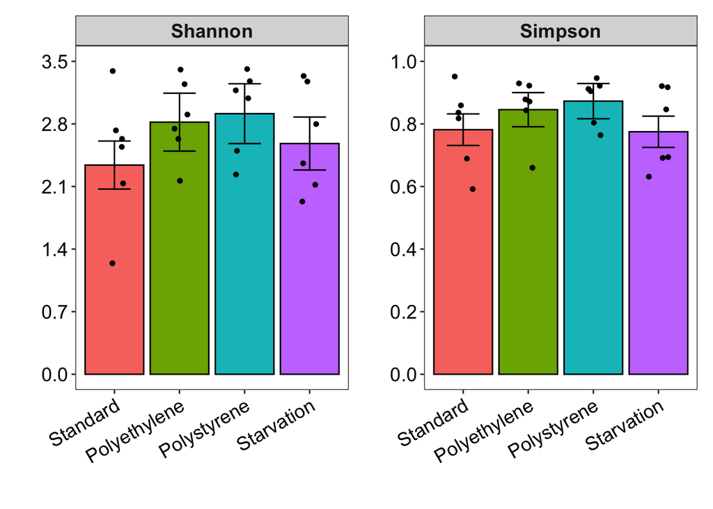

```r
# Collect the emmeans for Shannon data
emms.shannon <- as.data.frame(model.shannon.em$emmeans)
emms.shannon$metric <- 'Shannon'

# Collect the emmeans for teh Simpson's data
emms.simpson <- as.data.frame(model.simpson.em$emmeans)
emms.simpson$metric <- 'Simpson'

# Plot the Shannon data
p.shannon <- ggplot() +
  geom_bar(data = emms.shannon,
           aes(x = treatment, y = response, fill = treatment),
           stat = "identity",
           colour = "black") +
  geom_errorbar(data = emms.shannon,
                aes(x = treatment, ymin = response-SE, ymax = response+SE),
                stat = "identity", width = 0.5, size = 0.5) +
  geom_jitter(data = richness,
              aes(x = treatment, y = Shannon),
              width = 0.15, size = 1.25) +
  facet_wrap(~metric, scales="free_y") +
  theme_bw() +
  theme(text = element_text(size = 17), legend.position = "none",
        panel.grid.major = element_blank(),
        panel.grid.minor = element_blank(),
        strip.text.x = element_text(face="bold"),
        axis.text.x = element_text(angle = 30, vjust = 1, hjust = 1, color="black"),
        axis.text.y = element_text(color="black")) +
  scale_y_continuous(lim=c(0,3.5), breaks=c(0.0,0.7,1.4,2.1,2.8,3.5)) +
  xlab("") + ylab("")

# Plot the Simpson's data
p.simpson <- ggplot() +
  geom_bar(data = emms.simpson,
           aes(x = treatment, y = response, fill = treatment),
           stat = "identity",
           colour = "black") +
  geom_errorbar(data = emms.simpson,
                aes(x = treatment, ymin = response-SE, ymax = response+SE),
                stat = "identity", width = 0.5, size = 0.5) +
  geom_jitter(data = richness,
              aes(x = treatment, y = Simpson),
              width = 0.15, size = 1.25) +
  facet_wrap(~metric, scales="free_y") +
  theme_bw() +
  theme(text = element_text(size = 17), legend.position = "none",
        panel.grid.major = element_blank(),
        panel.grid.minor = element_blank(),
        strip.text.x = element_text(face="bold"),
        axis.text.x = element_text(angle = 30, vjust = 1, hjust = 1, color="black"),
        axis.text.y = element_text(color="black")) +
  scale_y_continuous(lim=c(0,1), breaks=c(0.0,0.2,0.4,0.6,0.8,1.0)) +
  xlab("") + ylab("")

# Combine the plots as two panels in one figure
p.shannon + p.simpson
```

```r
# Export a PDF of the figure
pdf('Superworm.alpha.pdf', width=10, height=5)
p.shannon + p.simpson
dev.off()
```

## Calculate and plot beta-diversity for the superworm data and perform statistical analysis

```r
# Calculate the bray curtis distances
dist_bc <- phyloseq::distance(ps.rel, method = "bray")

# Extract sample data
meta <- data.frame(sample_data(ps.rel))

# Perform a permutation test to test if the data meet the assumptions of PERMANOVA
beta.bray <- betadisper(dist_bc, meta$Treatment, type = "centroid", bias.adjust = TRUE)
permdisp <- permutest(beta.bray, pairwise = TRUE, permutations = 10000)
permdisp
```

```
##
## Permutation test for homogeneity of multivariate dispersions
## Permutation: free
## Number of permutations: 10000
##
## Response: Distances
##           Df   Sum Sq   Mean Sq     F N.Perm Pr(>F)
## Groups     3 0.010225 0.0034085 0.383  10000 0.7694
## Residuals 20 0.177967 0.0088983
##
## Pairwise comparisons:
## (Observed p-value below diagonal, permuted p-value above diagonal)
##              Polyethylene Polystyrene Standard Starvation
## Polyethylene                  0.54495  0.48985     0.7850
## Polystyrene       0.53713              0.82722     0.4793
## Standard          0.49579     0.82759              0.4431
## Starvation        0.78884     0.47717  0.44243
```

Unlike the mealworm data, the dispersion is not significantly different between samples, which means the results of PERMANOVA should be reliable.

```r
# Run the PERMANOVA test
adonis.bray <- adonis2(dist_bc ~ Treatment + Insect_batch, data = meta, permutations = 10000, by = "terms")
as.data.frame(adonis.bray)
```

```
##              Df  SumOfSqs        R2        F     Pr(>F)
## Treatment     3 0.4311319 0.1372575 1.688217 0.05389461
## Insect_batch  2 1.1776496 0.3749230 6.917123 0.00009999
## Residual     18 1.5322623 0.4878195       NA         NA
## Total        23 3.1410438 1.0000000       NA         NA
```

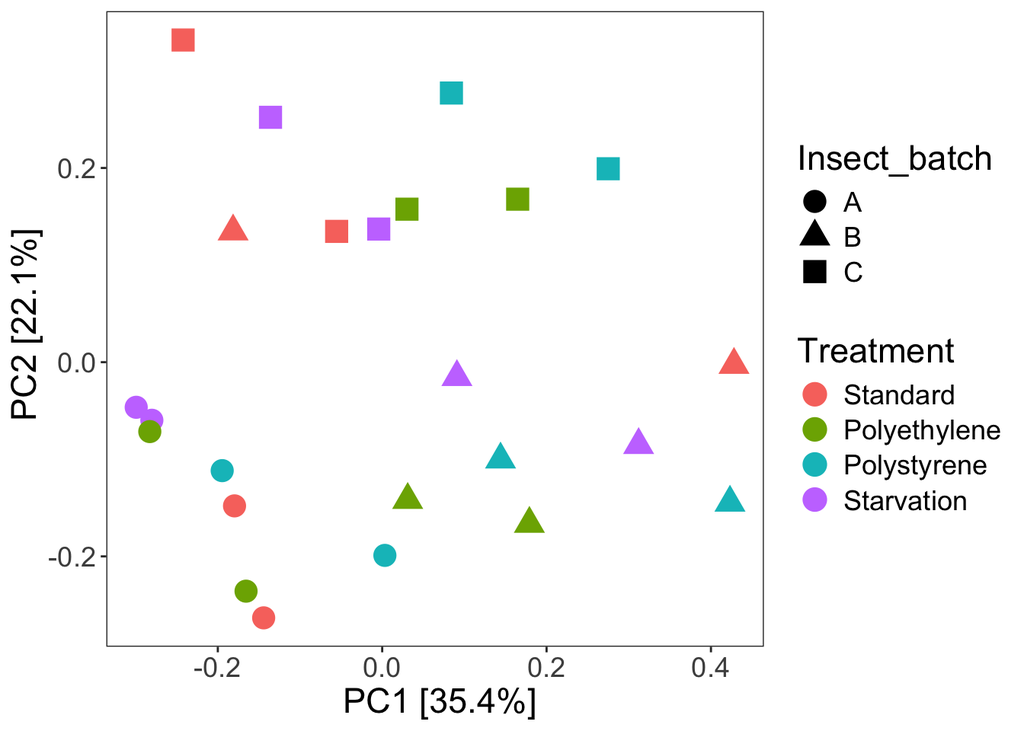

```r
# Create a PCoA plot
sample_data(ps.rel)$Treatment <- factor(sample_data(ps.rel)$Treatment,
                                        levels = c("Standard", "Polyethylene", "Polystyrene", "Starvation"))
pso <- ordinate(ps.rel, "PCoA", "bray")
var_explained <- pso$values$Relative_eig * 100
ordplot5 <- plot_ordination(ps.rel, pso, type="samples",
                            color="Treatment", shape="Insect_batch",
                            axes = c(1,2))
p.beta.pcoa <- ordplot5 +  theme_bw() + theme(text = element_text(size = 17), aspect.ratio = 1) +
  geom_point(size = 5) +
  theme_bw() +
  theme(text = element_text(size = 17),
        panel.grid.major = element_blank(),
        panel.grid.minor = element_blank(),
        legend.position = "right") +
  labs(x = paste0(" PC1 [", round(var_explained[1], 1), "%]"),
       y = paste0(" PC2 [", round(var_explained[2], 1), "%]"))
p.beta.pcoa
```

```r
# Save the figure
pdf('Superworm.beta.pcoa.pdf', width=10, height=5)
p.beta.pcoa
dev.off()
```

```r
# Set the formula for the model
class(fo <- dist_bc ~ meta$Treatment + meta$Insect_batch)
```

```
## [1] "formula"
```

```r
# Run the capscale analysis followed by an ANOVA
pso_cap <- ordinate(ps.rel, "CAP", "bray", formula=fo)
anova(pso_cap, by = "terms", type = 2)
```

```
## Permutation test for capscale under reduced model
## Terms added sequentially (first to last)
## Permutation: free
## Number of permutations: 999
##
## Model: capscale(formula = OTU ~ meta$Treatment + meta$Insect_batch, data = data, distance = distance)
##                   Df SumOfSqs      F Pr(>F)
## meta$Treatment     3  0.43894 1.6395  0.053 .
## meta$Insect_batch  2  1.18320 6.6291  0.001 ***
## Residual          18  1.60636
## ---
## Signif. codes:  0 '***' 0.001 '**' 0.01 '*' 0.05 '.' 0.1 ' ' 1
```

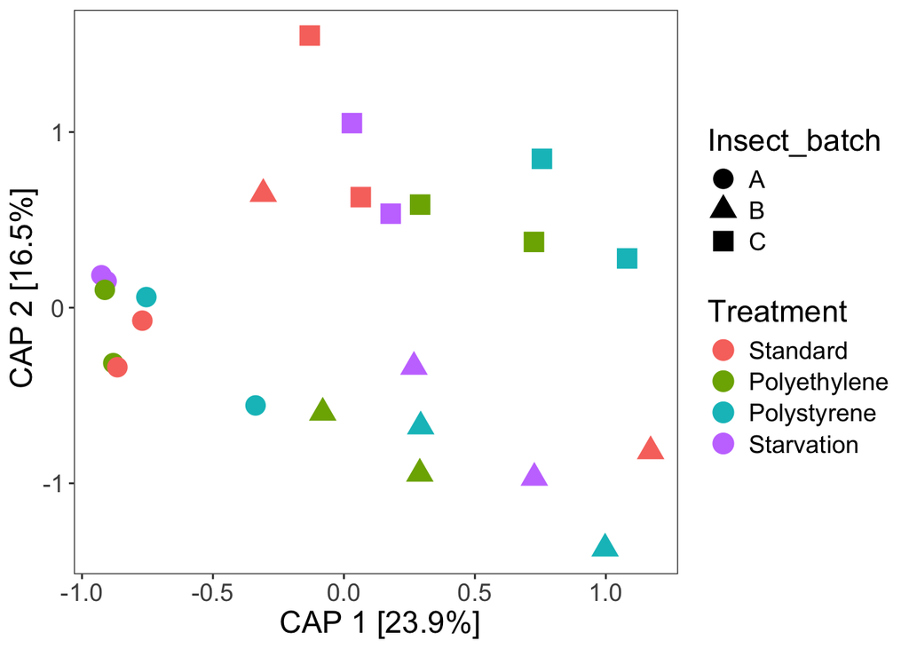

```r
# Get the relative eigenvalues
all_eig <- eigenvals(pso_cap)
rel_eig <- all_eig / sum(all_eig)
var_explained <- round(rel_eig * 100, 1)

# Plot the capscale results
ordplot5 <- plot_ordination(ps.rel, pso_cap, type="samples", color="Treatment",
                            shape="Insect_batch", axes = c(1,2))
p.beta.cap <- ordplot5 +  theme_bw() + theme(text = element_text(size = 17), aspect.ratio = 1) +
  geom_point(size = 5) +
  theme_bw() +
  theme(text = element_text(size = 17),
        panel.grid.major = element_blank(),
        panel.grid.minor = element_blank(),
        legend.position = "right") +
  labs(x = paste0(" CAP 1 [", round(var_explained[1], 1), "%]"),
       y = paste0(" CAP 2 [", round(var_explained[2], 1), "%]"))
p.beta.cap
```

```r
# Save the figure
pdf('Superworm.beta.cap.pdf', width=10, height=5)
p.beta.pcoa
dev.off()
```

Given the strong impact of batch, see what the PCoA and CAP plots look like if summarized at the genus level

```r
# Summarize at the genus level, removing taxa not classified at the genus level
ps.rel.genus <- tax_glom(ps.rel, "Genus", NArm = TRUE)

# Calculate the bray curtis distances
dist_bc <- phyloseq::distance(ps.rel.genus, method = "bray")

# Extract sample data
meta <- data.frame(sample_data(ps.rel.genus))

# Perform a permutation test to test if the data meet the assumptions of PERMANOVA
beta.bray <- betadisper(dist_bc, meta$Treatment, type = "centroid", bias.adjust = TRUE)
permdisp <- permutest(beta.bray, pairwise = TRUE, permutations = 10000)
permdisp
```

```
##
## Permutation test for homogeneity of multivariate dispersions
## Permutation: free
## Number of permutations: 10000
##
## Response: Distances
##           Df   Sum Sq   Mean Sq      F N.Perm Pr(>F)
## Groups     3 0.020585 0.0068617 0.7232  10000  0.556
## Residuals 20 0.189765 0.0094883
##
## Pairwise comparisons:
## (Observed p-value below diagonal, permuted p-value above diagonal)
##              Standard Polyethylene Polystyrene Starvation
## Standard                   0.39906     0.51075     0.2305
## Polyethylene  0.40113                  0.95100     0.4554
## Polystyrene   0.51580      0.94916                 0.5216
## Starvation    0.23234      0.45331     0.52514
```

```r
# Run the PERMANOVA test
adonis.bray <- adonis2(dist_bc ~ Treatment + Insect_batch, data = meta, permutations = 10000, by = "terms")
as.data.frame(adonis.bray)
```

```
##              Df  SumOfSqs        R2        F     Pr(>F)
## Treatment     3 0.2878599 0.1228396 1.459434 0.14868513
## Insect_batch  2 0.8720750 0.3721441 6.632057 0.00009999
## Residual     18 1.1834451 0.5050163       NA         NA
## Total        23 2.3433801 1.0000000       NA         NA
```

```r
# Create a PCoA plot
pso <- ordinate(ps.rel.genus, "PCoA", "bray")
var_explained <- pso$values$Relative_eig * 100
ordplot5 <- plot_ordination(ps.rel.genus, pso, type="samples",
                            color="Treatment", shape="Insect_batch",
                            axes = c(1,2))
p.beta.pcoa.genus <- ordplot5 + theme_bw() +
  theme(text = element_text(size = 17), aspect.ratio = 1) +
  geom_point(size = 5) +
  theme_bw() +
  theme(text = element_text(size = 17),
        panel.grid.major = element_blank(),
        panel.grid.minor = element_blank(),
        legend.position = "none") +
  labs(x = paste0(" PC1 [", round(var_explained[1], 1), "%]"),
       y = paste0(" PC2 [", round(var_explained[2], 1), "%]"))

# Set the formula for the model for the capscale analysis
class(fo <- dist_bc ~ meta$Treatment + meta$Insect_batch)
```

```
## [1] "formula"
```

```r
# Run the capscale analysis followed by an ANOVA
pso_cap <- ordinate(ps.rel.genus, "CAP", "bray", formula=fo)
anova(pso_cap, by = "terms", type = 2)
```

```
## Permutation test for capscale under reduced model
## Terms added sequentially (first to last)
## Permutation: free
## Number of permutations: 999
##
## Model: capscale(formula = OTU ~ meta$Treatment + meta$Insect_batch, data = data, distance = distance)
##                   Df SumOfSqs      F Pr(>F)
## meta$Treatment     3  0.29317 1.3998  0.194
## meta$Insect_batch  2  0.87755 6.2851  0.001 ***
## Residual          18  1.25661
## ---
## Signif. codes:  0 '***' 0.001 '**' 0.01 '*' 0.05 '.' 0.1 ' ' 1
```

```r
# Get the relative eigenvalues
all_eig <- eigenvals(pso_cap)
rel_eig <- all_eig / sum(all_eig)
var_explained <- round(rel_eig * 100, 1)

# Plot the capscale results
ordplot5 <- plot_ordination(ps.rel.genus, pso_cap, type="samples", color="Treatment",
                            shape="Insect_batch", axes = c(1,2))
p.beta.cap.genus <- ordplot5 + theme_bw() +
  theme(text = element_text(size = 17), aspect.ratio = 1) +
  geom_point(size = 5) +
  theme_bw() +
  theme(text = element_text(size = 17),
        panel.grid.major = element_blank(),
        panel.grid.minor = element_blank(),
        legend.position = "none") +
  labs(x = paste0(" CAP 1 [", round(var_explained[1], 1), "%]"),
       y = paste0(" CAP 2 [", round(var_explained[2], 1), "%]"))
```

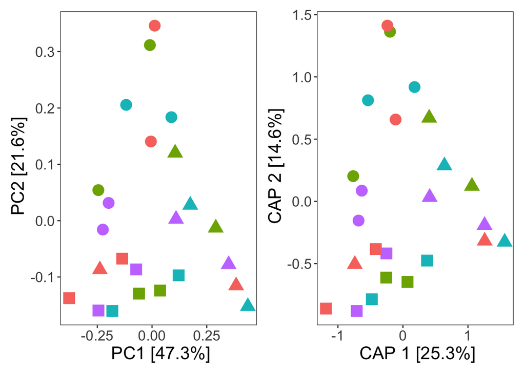

```r
# Display both graphs
p.beta.pcoa.genus + p.beta.cap.genus
```

```r
# Save the figure
pdf('Superworm.beta.genus.pdf', width=10, height=5)
p.beta.pcoa.genus + p.beta.cap.genus
dev.off()
```

## Compare taxon abundance in the superworm data

Summarize the most abundant taxa at the phylum level in the superworms across diets.

```r
# Agglomerate data at phylum level
ps.rel.phylum <- tax_glom(ps.rel, "Phylum", NArm = FALSE)

# Create a dataframe from phyloseq object
ps.rel.phylum.df <- psmelt(ps.rel.phylum)

# Get summary statistics
df <- ps.rel.phylum.df %>%
  group_by(Treatment, Phylum) %>%
  summarize(mean = mean(Abundance, na.rm = TRUE),
            median = median(Abundance, na.rm = TRUE),
            stdev = sd(Abundance, na.rm = TRUE),
            counts = n(),
            se = stdev / sqrt(counts))

# Create a table rounded to 1 decimal place
df.w <- df %>%
  mutate(stat = paste0(round(100 * mean, 1), " +/- ", round(100 * stdev, 1))) %>%
  select(Treatment, Phylum, stat) %>%
  pivot_wider(
    names_from = Treatment,
    values_from = stat
  )
kable(df.w, digits = 1, align = "l",
      caption = "test") %>%
  kable_classic(full_width = FALSE)
```

test

| Phylum | Standard | Polyethylene | Polystyrene | Starvation |
| --- | --- | --- | --- | --- |
| Actinomycetota | 0.6 +/- 0.5 | 0.9 +/- 0.6 | 0.8 +/- 0.9 | 1.5 +/- 1 |
| Bacillota | 69.9 +/- 22.7 | 65 +/- 20 | 56.8 +/- 19.8 | 69.2 +/- 21.2 |
| Bacteroidota | 4 +/- 2.9 | 5.7 +/- 2.5 | 6.7 +/- 3.9 | 4.9 +/- 1.7 |
| Fusobacteriota | 0.5 +/- 0.4 | 0.2 +/- 0.2 | 0.3 +/- 0.2 | 0.2 +/- 0.1 |
| Pseudomonadota | 25 +/- 20.4 | 28.3 +/- 18 | 35.4 +/- 17 | 24.2 +/- 19.8 |

```r
# Create a table rounded to 6 decimal place
df.w <- df %>%
  mutate(stat = paste0(round(100 * mean, 6), " +/- ", round(100 * stdev, 6))) %>%
  select(Treatment, Phylum, stat) %>%
  pivot_wider(
    names_from = Treatment,
    values_from = stat
  )
kable(df.w, digits = 6, align = "l",
      caption = "test") %>%
  kable_classic(full_width = FALSE)
```

test

| Phylum | Standard | Polyethylene | Polystyrene | Starvation |
| --- | --- | --- | --- | --- |
| Actinomycetota | 0.584051 +/- 0.512541 | 0.873813 +/- 0.566816 | 0.84563 +/- 0.883084 | 1.512163 +/- 0.9867 |
| Bacillota | 69.926556 +/- 22.696061 | 64.991856 +/- 20.029372 | 56.804631 +/- 19.772265 | 69.211542 +/- 21.217374 |
| Bacteroidota | 4.007498 +/- 2.86005 | 5.675606 +/- 2.532881 | 6.713579 +/- 3.864712 | 4.87894 +/- 1.749094 |
| Fusobacteriota | 0.462348 +/- 0.389987 | 0.206094 +/- 0.174084 | 0.269365 +/- 0.201808 | 0.221589 +/- 0.127233 |
| Pseudomonadota | 25.019547 +/- 20.38401 | 28.252631 +/- 17.974738 | 35.366795 +/- 17.017586 | 24.175767 +/- 19.82446 |

```r
# Get overall summary statistics not divided by diet
df <- ps.rel.phylum.df %>%
  group_by(Phylum) %>%
  summarize(mean = 100 * mean(Abundance, na.rm = TRUE),
            stdev = 100 * sd(Abundance, na.rm = TRUE),
            counts = n(),
            se = stdev / sqrt(counts))
kable(df, digits = 6, align = "l",
      caption = "test") %>%
  kable_classic(full_width = FALSE)
```

test

| Phylum | mean | stdev | counts | se |
| --- | --- | --- | --- | --- |
| Actinomycetota | 0.953914 | 0.793628 | 24 | 0.161999 |
| Bacillota | 65.233646 | 20.259999 | 24 | 4.135555 |
| Bacteroidota | 5.318905 | 2.850383 | 24 | 0.581832 |
| Fusobacteriota | 0.289849 | 0.250881 | 24 | 0.051211 |
| Pseudomonadota | 28.203685 | 18.144451 | 24 | 3.703720 |

## Differential abundance analysis of taxa in the superworm data

```r
# Set abundance filter function, filtering based on an average relative abundance ≥ 0.01%
abundance_filter_function <- function(x) {
  mean(x) >= 0.0001
}

# Filter the MAG data to a minimum average relative abundance of 0.01%
ps.rel.filtered <- filter_taxa(ps.rel, abundance_filter_function, prune = TRUE)

# Set the factors to get standard as the reference
sample_data(ps.rel.filtered)$Treatment <- factor(sample_data(ps.rel.filtered)$Treatment,
                                                 levels = c("Standard", "Polyethylene",
                                                            "Polystyrene","Starvation"))

# Run ANCOMBC2 with standard as teh reference
ancombc.standard <- ancombc2(data = ps.rel.filtered,
                             fix_formula = "Treatment",
                             rand_formula = "(1 | Insect_batch/Replicate)",
                             p_adj_method = "BH",
                             alpha = 0.025,
                             global = FALSE)
ancombc.standard.res <- ancombc.standard$res

# Set the factors to get standard as the reference
sample_data(ps.rel.filtered)$Treatment <- factor(sample_data(ps.rel.filtered)$Treatment,
                                                 levels = c("Starvation", "Polyethylene",
                                                            "Polystyrene","Standard"))

# Run ANCOMBC2 with standard as the reference
ancombc.starvation <- ancombc2(data = ps.rel.filtered,
                             fix_formula = "Treatment",
                             rand_formula = "(1 | Insect_batch/Replicate)",
                             p_adj_method = "BH",
                             alpha = 0.025,
                             global = FALSE)
ancombc.starvation.res <- ancombc.starvation$res

# Get differentialy abundant taxa for PE
taxa.diff_abn.PE = data.frame()
for(n in 1:nrow(ancombc.standard.res)) {
  if(ancombc.standard.res$diff_TreatmentPolyethylene[n] == TRUE &
     ancombc.standard.res$passed_ss_TreatmentPolyethylene[n] == TRUE &
     ancombc.starvation.res$diff_TreatmentPolyethylene[n] == TRUE &
     ancombc.starvation.res$passed_ss_TreatmentPolyethylene[n] == TRUE) {
    taxa.diff_abn.PE <- rbind(taxa.diff_abn.PE, res.asv$taxon[n])
  }
}

# Print the results for PE
if(nrow(taxa.diff_abn.PE) == 0) {
  print("No MAGs met the criteria for differential abundance for PE")
} else {
  print(taxa.diff_abn.PE)
}
```

```
## [1] "No MAGs met the criteria for differential abundance for PE"
```

```r
# Get differentialy abundant taxa for PS
taxa.diff_abn.PS = data.frame()
for(n in 1:nrow(ancombc.standard.res)) {
  if(ancombc.standard.res$diff_TreatmentPolyethylene[n] == TRUE &
     ancombc.standard.res$passed_ss_TreatmentPolyethylene[n] == TRUE &
     ancombc.starvation.res$diff_TreatmentPolyethylene[n] == TRUE &
     ancombc.starvation.res$passed_ss_TreatmentPolyethylene[n] == TRUE) {
    taxa.diff_abn.PS <- rbind(taxa.diff_abn.PS, res.asv$taxon[n])
  }
}

# Print the results for PS
if(nrow(taxa.diff_abn.PS) == 0) {
  print("No MAGs met the criteria for differential abundance for PS")
} else {
  print(taxa.diff_abn.PS)
}
```

```
## [1] "No MAGs met the criteria for differential abundance for PS"
```

Summarize the data at the species level and then test whether any species are enriched in the PE or PS diets relative to both the starvation and standard diets.

```r
# Summarize at the species level, removing taxa not classified at the species level
ps.rel.species <- tax_glom(ps.rel, "Species", NArm = TRUE)

# Set abundance filter function, filtering based on an average relative abundance ≥ 0.01%
abundance_filter_function <- function(x) {
  mean(x) >= 0.0001
}

# Filter the MAG data to a minimum average relative abundance of 0.01%
ps.rel.filtered <- filter_taxa(ps.rel.species, abundance_filter_function, prune = TRUE)

# Set the factors to get standard as the reference
sample_data(ps.rel.filtered)$Treatment <- factor(sample_data(ps.rel.filtered)$Treatment,
                                                 levels = c("Standard", "Polyethylene",
                                                            "Polystyrene","Starvation"))

# Run ANCOMBC2 with standard as teh reference
ancombc.standard <- ancombc2(data = ps.rel.filtered,
                             fix_formula = "Treatment",
                             rand_formula = "(1 | Insect_batch/Replicate)",
                             p_adj_method = "BH",
                             alpha = 0.025,
                             global = FALSE)
ancombc.standard.res <- ancombc.standard$res

# Set the factors to get standard as the reference
sample_data(ps.rel.filtered)$Treatment <- factor(sample_data(ps.rel.filtered)$Treatment,
                                                 levels = c("Starvation", "Polyethylene",
                                                            "Polystyrene","Standard"))

# Run ANCOMBC2 with standard as the reference
ancombc.starvation <- ancombc2(data = ps.rel.filtered,
                             fix_formula = "Treatment",
                             rand_formula = "(1 | Insect_batch/Replicate)",
                             p_adj_method = "BH",
                             alpha = 0.025,
                             global = FALSE)
ancombc.starvation.res <- ancombc.starvation$res

# Get differentialy abundant taxa for PE
taxa.diff_abn.species.PE = data.frame()
for(n in 1:nrow(ancombc.standard.res)) {
  if(ancombc.standard.res$diff_TreatmentPolyethylene[n] == TRUE &
     ancombc.standard.res$passed_ss_TreatmentPolyethylene[n] == TRUE &
     ancombc.starvation.res$diff_TreatmentPolyethylene[n] == TRUE &
     ancombc.starvation.res$passed_ss_TreatmentPolyethylene[n] == TRUE) {
    taxa.diff_abn.species.PE <- rbind(taxa.diff_abn.species.PE, res.asv$taxon[n])
  }
}

# Print the results for PE
if(nrow(taxa.diff_abn.species.PE) == 0) {
  print("No species met the criteria for differential abundance for PE")
} else {
  print(taxa.diff_abn.species.PE)
}
```

```
## [1] "No species met the criteria for differential abundance for PE"
```

```r
# Get differentialy abundant taxa for PS
taxa.diff_abn.species.PS = data.frame()
for(n in 1:nrow(ancombc.standard.res)) {
  if(ancombc.standard.res$diff_TreatmentPolyethylene[n] == TRUE &
     ancombc.standard.res$passed_ss_TreatmentPolyethylene[n] == TRUE &
     ancombc.starvation.res$diff_TreatmentPolyethylene[n] == TRUE &
     ancombc.starvation.res$passed_ss_TreatmentPolyethylene[n] == TRUE) {
    taxa.diff_abn.species.PS <- rbind(taxa.diff_abn.species.PS, res.asv$taxon[n])
  }
}

# Print the results for PS
if(nrow(taxa.diff_abn.species.PS) == 0) {
  print("No species met the criteria for differential abundance for PS")
} else {
  print(taxa.diff_abn.species.PS)
}
```

```
## [1] "No species met the criteria for differential abundance for PS"
```

## Clean the workspace to switch to CFU analysis

```r
rm(list = ls())
```

# Analysis of CFU counts per insect